# SPC Exp1

Mrudula

07 October,2021

**This contains the analysis script of the first experiment in the Sensory pre conditioning series**

Can associated stimuli indirectly retrieve a response with another paired stimulus? : Transfer of associations and indirect retrieval using contingency learning

#### DATA PREPARATION

- Unnecessary columns are removed from the main dataframe
- The Reaction Time columns are saved again such that the values from Phase 1 (Saved as SSResp.rt) and values from Phase 2 and 3 (saved as REsponse.rt) are combined into one column named RT_Trials. So a dummy variable is created to identify rows with Phase 1 RT and Phase2&3 RT to later combine together as RT_Trials.
- Similar process is done for Accuracy
- Error Rate column is created

### DESCRIPTIVES

```r
Exp1data <- Exp1data%>%drop_na(RT_Trials)

pander(summary(Exp1data$Age),style = 'rmarkdown', caption = "Age")
```

Age

| Min. | 1st Qu. | Median | Mean | 3rd Qu. | Max. |
| --- | --- | --- | --- | --- | --- |
| 18 | 20 | 22 | 24.54 | 29 | 35 |

```r
pander(summary(Exp1data$RT_Trials), style = 'rmarkdown',caption = 'Mean RT')
```

Mean RT

| Min. | 1st Qu. | Median | Mean | 3rd Qu. | Max. |
| --- | --- | --- | --- | --- | --- |
| 1 | 406.8 | 479.3 | 526.7 | 577.4 | 20026 |

```r
pander(table(Exp1data$ACC_trials),style = 'rmarkdown',caption = "Accuracy")
```

Accuracy

| 0 | 1 |
| --- | --- |
| 1641 | 29315 |

```r
pander(round(table(Exp1data$ACC_trials)/nrow(Exp1data)*100, digits = 3), style = 'rmarkdown', caption = "Percentage of errors")
```

Percentage of errors

| 0 | 1 |
| --- | --- |
| 5.301 | 94.7 |

#### OUTLIERS AND EXCLUSIONS

```r
#incorrect trials RT are not used

Exp1data$RT_Trials[Exp1data$ACC_trials==0] <- NA

#creating function to remove the outliers and farouts
computeTukeys <- function(x){
  P25 <- quantile(x$RT_Trials, .25, na.rm = TRUE, type = 6) #type = 6 -> used in SPSS
  P75 <- quantile(x$RT_Trials, .75, na.rm = TRUE, type = 6)
  x$Outlier <- P75 + 1.5*(P75 - P25)
  x$Farouts <- P75 + 3.0*(P75 - P25)
  return(x)
}


#identifying the outliers and farouts at individual level
Exp1data <- ddply(Exp1data, .(PROLIFIC_PID), computeTukeys)

#creating new column with RT trials after removing outliers/farouts
Exp1data$RT_ifo <- Exp1data$RT_Trials #ifo refers to individual farouts
Exp1data$RT_io <- Exp1data$RT_Trials #io refers to individual outliers


#RTs above outliers and farouts and very fast RTs below 200ms
Exp1data <- Exp1data %>%
  mutate(RT_ifo = ifelse((RT_ifo > Farouts)|(RT_ifo < 200),NA,RT_ifo),
         RT_io = ifelse((RT_io > Outlier)|(RT_io < 200),NA, RT_io))


#printing the summary table for RTs columns in rmarkdown style after exluding outliers and farouts
pander(summary(Exp1data$RT_ifo), style = 'rmarkdown', caption = "Summary of RT after removing Farouts")
```

Summary of RT after removing Farouts

| Min. | 1st Qu. | Median | Mean | 3rd Qu. | Max. | NA’s |
| --- | --- | --- | --- | --- | --- | --- |
| 200 | 413.3 | 480 | 508.7 | 570.1 | 1639 | 2467 |

```r
pander(summary(Exp1data$RT_io), style = 'rmarkdown', caption = "Summary of RT after removing Outliers")
```

Summary of RT after removing Outliers

| Min. | 1st Qu. | Median | Mean | 3rd Qu. | Max. | NA’s |
| --- | --- | --- | --- | --- | --- | --- |
| 200 | 409.2 | 472 | 494 | 556.1 | 1187 | 3476 |

# Manipulation Checks

## 1. Phase 1

First checking whether participants picked up on the association between **S1-S2** by looking at the contingency effect in Phase 1.

The word pairs were:

> High(S1) + fair(S2) even(S1) + warm(S2)

> Both the results show that the performance is better in valid than in invalid trials indicating that the participants picked up on the association between S1-s2 and used the predictive property of S1

```r
#aggregating the RT and ER in Phase 1
Exp1_phase1 <- Exp1data %>%
  group_by(PROLIFIC_PID,Validity) %>%
  filter(Phase == 1) %>%
  summarise(ER= mean(ER,na.rm=TRUE),
            RT = mean(RT_io, na.rm = TRUE))

# Paired T test in RTs between Valid and invalid Pairs
pander((t.test(data = Exp1_phase1, RT~Validity,paired = TRUE)), style = 'rmarkdown', caption = "t test showing differences between valid and invalid trials-excluding outliers")
```

t test showing differences between valid and invalid trials-excluding outliers (continued below)

| Test statistic | df | P value | Alternative hypothesis |
| --- | --- | --- | --- |
| 6.156 | 70 | 4.142e-08 * * * | two.sided |

| mean of the differences |
| --- |
| 32.81 |

```r
valmain <- ggplot(Exp1_phase1, aes(x=Validity, y=RT))+
  geom_bar(stat = "summary", fun = "mean", fill = "midnightblue")+
  coord_cartesian(ylim = c(400,600))+
  theme_classic()+
  xlab("S1-S2 pair validity")+
  ylab("ReactionTime (in ms)")+
  ggtitle("Mean of valid and invalid trials \n in Phase 1")+
  theme(text = element_text(size = 20))


# for error rate
pander((t.test(data = Exp1_phase1, ER~Validity,paired = TRUE)), style = 'rmarkdown', caption = "t test showing differences between valid and invalid trials-error rate")
```

t test showing differences between valid and invalid trials-error rate (continued below)

| Test statistic | df | P value | Alternative hypothesis |
| --- | --- | --- | --- |
| 3.388 | 70 | 0.001158 * * | two.sided |

| mean of the differences |
| --- |
| 0.03995 |

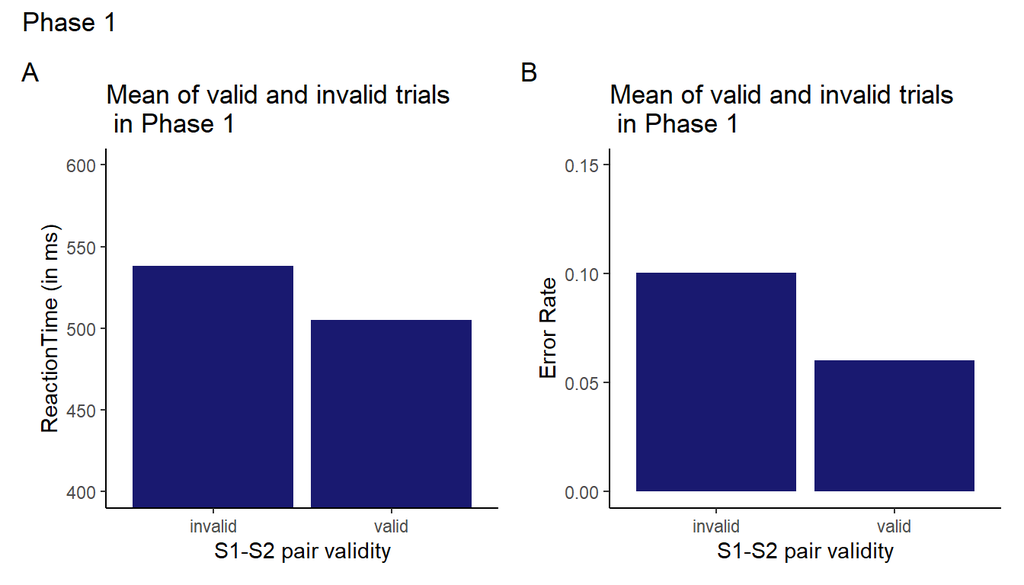

```r
valmainer <- ggplot(Exp1_phase1, aes(x=Validity, y=ER))+
  geom_bar(stat = "summary", fun = "mean", fill = "midnightblue")+
  coord_cartesian(ylim = c(0,0.15))+
  theme_classic()+
  xlab("S1-S2 pair validity")+
  ylab("Error Rate")+
  ggtitle("Mean of valid and invalid trials \n in Phase 1")+
  theme(text = element_text(size = 20))


Phase1Fig <- (valmain + valmainer) +
  plot_annotation(tag_levels = "A", title = "Phase 1")+
  plot_layout(guides = "collect") & theme_classic()

Phase1Fig
```

## 2. Phase 2: S2-R contingency check

Paired t test shows that there is a contingency effect for **S2-R** while comparing valid and invalid trials which is significant $t = 10.6, p <.001$ with a mean difference of ~39 ms

Similarly while looking at errors as well there is a significant difference $t = 4.50, p < .001$

This shows that the participants successfully bound the contingent response with the S2 in Phase 2.

```r
# aggregate file with RT and ER for phase 2

Exp1_phase2 <- Exp1data %>%
  group_by(PROLIFIC_PID,Validity) %>%
  filter(Phase == 2) %>%
  summarise(ER= mean(ER,na.rm=TRUE),
            RT = mean(RT_io, na.rm = TRUE))
#paired ttest
pander((t.test(data = Exp1_phase2, RT~Validity,paired = TRUE)), style = 'rmarkdown', caption = "t test showing differences between valid and invalid trials-excluding outliers")
```

t test showing differences between valid and invalid trials-excluding outliers (continued below)

| Test statistic | df | P value | Alternative hypothesis |
| --- | --- | --- | --- |
| 10.6 | 70 | 3.372e-16 * * * | two.sided |

| mean of the differences |
| --- |
| 39.63 |

```r
valmain2 <- ggplot(Exp1_phase2, aes(x=Validity, y=RT))+
   geom_bar(stat = "summary", fun = "mean", fill = "midnightblue")+
  coord_cartesian(ylim = c(400,600))+
  theme_classic()+
  xlab("S2-R validity")+
  ylab("ReactionTime (in ms)")+
  ggtitle("Mean of valid and invalid trials \n in Phase 2")+
  theme(text = element_text(size = 20))


## for Error RAte
pander((t.test(data = Exp1_phase2, ER~Validity,paired = TRUE)), style = 'rmarkdown', caption = "t test showing differences between valid and invalid trials-error rate")
```

t test showing differences between valid and invalid trials-error rate (continued below)

| Test statistic | df | P value | Alternative hypothesis |
| --- | --- | --- | --- |
| 4.509 | 70 | 2.554e-05 * * * | two.sided |

| mean of the differences |
| --- |
| 0.04173 |

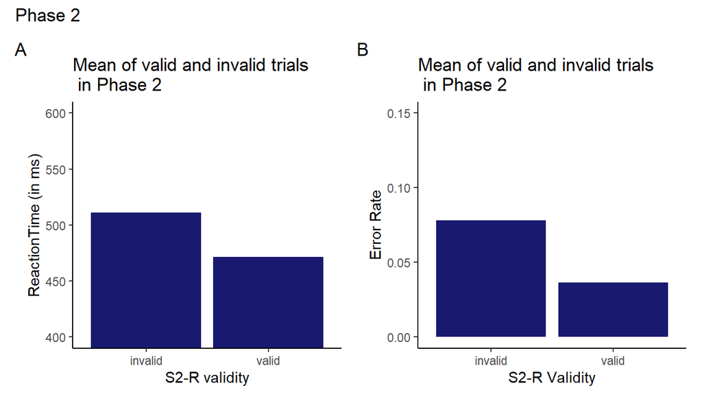

```r
valmain2er <- ggplot(Exp1_phase2, aes(x=Validity, y=ER))+
  geom_bar(stat = "summary", fun = "mean", fill = "midnightblue")+
  coord_cartesian(ylim = c(0,0.15))+
  theme_classic()+
  xlab("S2-R Validity")+
  ylab("Error Rate")+
  ggtitle("Mean of valid and invalid trials \n in Phase 2")+
  theme(text = element_text(size = 20))


Phase2Fig <- (valmain2+valmain2er)+
  plot_annotation(tag_levels = "A", title = "Phase 2")+
  plot_layout(guides = "collect")&theme_classic()

Phase2Fig
```

## Phase 3.1 : Checking for sustainance of S2-R Contingency effect

While only looking at the S2 trials, a t.test was conducted to compare the performance in the valid and invalid trials to check for a possible contingency effect that might have carried forward into Phase 3, where S1 was also present.

The t.test revealed that there is a significant difference between valid and invalid trials for S2 and that the contingency effect remains significant $t = 6.773, p <.001$ for RT and $t = 4.13,p < 0.001$ for ER.

```r
Exp1_phase3.1 <- Exp1data %>%
  group_by(PROLIFIC_PID,Validity,Condition) %>%
  filter(Phase == 3.1) %>%
  summarise(ER= mean(ER,na.rm=TRUE),
            RT = mean(RT_io, na.rm = TRUE)) %>%
  rename(StimulusType = Condition)

pander((t.test(data = Exp1_phase3.1, RT~Validity,subset = (StimulusType == "S2-R Transfer"),paired = TRUE, alternative = "greater")), style = 'rmarkdown', caption = "t test showing differences between valid and invalid trials for S2-excluding outliers")
```

t test showing differences between valid and invalid trials for S2-excluding outliers (continued below)

| Test statistic | df | P value | Alternative hypothesis |
| --- | --- | --- | --- |
| 6.773 | 70 | 1.615e-09 * * * | greater |

| mean of the differences |
| --- |
| 34.34 |

```r
valmain3 <- ggplot(subset(Exp1_phase3.1,StimulusType == "S2-R Transfer"),
                   aes(x=Validity, y=RT))+
  geom_bar(stat = "summary", fun = "mean", fill = "midnightblue")+
  coord_cartesian(ylim = c(450,550))+
  theme_classic()+
  ylab("ReactionTime (in ms)")+
  ggtitle("Mean of valid and invalid trials \n in Phase 3.1 for S2")+
  theme(text = element_text(size = 20))


## Error Rate
pander((t.test(data = Exp1_phase3.1, ER~Validity,subset = (StimulusType == "S2-R Transfer"),paired = TRUE, alternative = "greater")), style = 'rmarkdown', caption = "t test showing differences between valid and invalid trials(ER) for S2-Error Rate")
```

t test showing differences between valid and invalid trials(ER) for S2-Error Rate (continued below)

| Test statistic | df | P value | Alternative hypothesis |
| --- | --- | --- | --- |
| 4.134 | 70 | 4.874e-05 * * * | greater |

| mean of the differences |
| --- |
| 0.06382 |

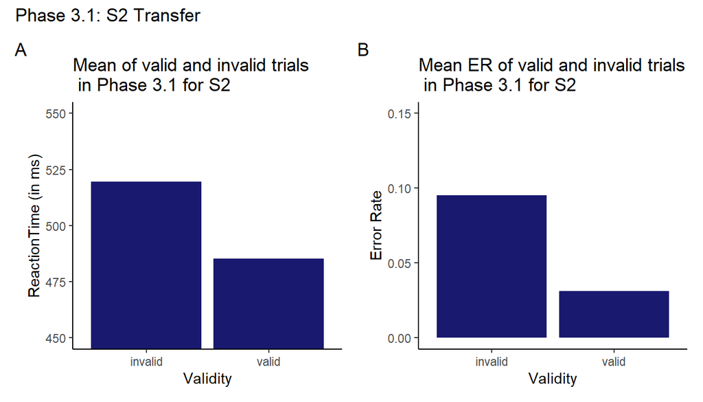

```r
valmain3er <- ggplot(subset(Exp1_phase3.1, StimulusType == "S2-R Transfer"), aes(x=Validity, y=ER))+
  geom_bar(stat = "summary", fun = "mean", fill = "midnightblue")+
  coord_cartesian(ylim = c(0,0.15))+
  theme_classic()+
  ylab("Error Rate")+
  ggtitle("Mean ER of valid and invalid trials \n in Phase 3.1 for S2")+
  theme(text = element_text(size = 20))

Phase31_s2 <- ((valmain3)+(valmain3er))+
  plot_annotation(tag_levels = "A", title = "Phase 3.1: S2 Transfer")+
  plot_layout(guides = "collect")&theme_classic()

Phase31_s2
```

# Transfer ANALYSES

## 1. Comparing contingency effects between stimulus types in Phase 3.1

### Reaction Time

This is also seen in the significant interaction between validity and stimulus type $F = 40.09, p < .001$

```r
## Reaction Time
anova31RT <- ezANOVA(data = Exp1_phase3.1,
                   dv = RT,
                   wid = PROLIFIC_PID,
                   within = .(Validity,StimulusType),
                   detailed = TRUE)
pander(anova_out(anova31RT), style = "rmarkdown", caption = "ANOVA (RT): for Phase 3.1 across stimulus type")
```

$`--- ANOVA RESULTS ------------------------------------` Effect MSE df1 df2 F p petasq getasq 1 (Intercept) 18352.6771 1 70 3835.36 0.000 0.98 0.98 2 Validity 715.5864 1 70 22.68 0.000 0.24 0.01 3 StimulusType 927.8947 1 70 6.34 0.014 0.08 0.00 4 Validity:StimulusType 654.1714 1 70 40.09 0.000 0.36 0.02

$`--- SPHERICITY TESTS ------------------------------------` [1] “N/A”

$`--- FORMATTED RESULTS ------------------------------------` Effect Text 1 (Intercept) F(1, 70) = 3835.36, p < .001, np2 = .98 2 Validity F(1, 70) = 22.68, p < .001, np2 = .24 3 StimulusType F(1, 70) = 6.34, p = .014, np2 = .08 4 Validity:StimulusType F(1, 70) = 40.09, p < .001, np2 = .36

$`NOTE:` [1] “Reporting unadjusted p-values.”

- **— ANOVA RESULTS ————————————**:

  | Effect | MSE | df1 | df2 | F | p | petasq | getasq |
  | --- | --- | --- | --- | --- | --- | --- | --- |
  | (Intercept) | 18353 | 1 | 70 | 3835.36 | 0.000 | 0.98 | 0.98 |
  | Validity | 715.6 | 1 | 70 | 22.68 | 0.000 | 0.24 | 0.01 |
  | StimulusType | 927.9 | 1 | 70 | 6.34 | 0.014 | 0.08 | 0.00 |
  | Validity:StimulusType | 654.2 | 1 | 70 | 40.09 | 0.000 | 0.36 | 0.02 |

- **— SPHERICITY TESTS ————————————**: N/A
- **— FORMATTED RESULTS ————————————**:

  | Effect | Text |
  | --- | --- |
  | (Intercept) | F(1, 70) = 3835.36, p < .001, np2 = .98 |
  | Validity | F(1, 70) = 22.68, p < .001, np2 = .24 |
  | StimulusType | F(1, 70) = 6.34, p = .014, np2 = .08 |
  | Validity:StimulusType | F(1, 70) = 40.09, p < .001, np2 = .36 |

- **NOTE:**: Reporting unadjusted p-values.

```r
anova_out(anova31RT)
```

```
## $`--- ANOVA RESULTS     ------------------------------------`
##                  Effect        MSE df1 df2       F     p petasq getasq
## 1           (Intercept) 18352.6771   1  70 3835.36 0.000   0.98   0.98
## 2              Validity   715.5864   1  70   22.68 0.000   0.24   0.01
## 3          StimulusType   927.8947   1  70    6.34 0.014   0.08   0.00
## 4 Validity:StimulusType   654.1714   1  70   40.09 0.000   0.36   0.02
##
## $`--- SPHERICITY TESTS  ------------------------------------`
## [1] "N/A"
##
## $`--- FORMATTED RESULTS ------------------------------------`
##                  Effect                                    Text
## 1           (Intercept) F(1, 70) = 3835.36, p < .001, np2 = .98
## 2              Validity F(1, 70) =   22.68, p < .001, np2 = .24
## 3          StimulusType F(1, 70) =    6.34, p = .014, np2 = .08
## 4 Validity:StimulusType F(1, 70) =   40.09, p < .001, np2 = .36
##
## $`NOTE:`
## [1] "Reporting unadjusted p-values."
```

```r
mean3_1 <- summarySEwithin(Exp1_phase3.1, measurevar= "RT", withinvars=c("Validity","StimulusType"), idvar="PROLIFIC_PID", na.rm=FALSE, conf.interval=.95)

inter3.1 <- ggplot(mean3_1, aes(x=StimulusType, y=RT,fill = Validity))+
  geom_bar(stat = "identity",position = position_dodge())+
  geom_errorbar(aes(ymin = RT - ci, ymax = RT + ci),width = .1, size = 1,position = position_dodge(.9))+
  scale_fill_manual(values = c("midnightblue","skyblue"))+
  coord_cartesian(ylim = c(400,550))+
  ggtitle("Valid and Invalid trials mean \n per Stimulus Type in Phase 3.1")+
  theme_classic()+
  ylab("ReactionTime (in ms)")+
  xlab("StimulusType")+
  theme(text = element_text(size = 20))
```

### Error Rate

In the case of Error rate, there is still the main effect of validity, $F = 20.01, p <.001$ but no main effect of stimulus type $F = 2.06, p = .156$. There is also a significant interaction between validity and stimulus type, $F = 7.79, p = .007$.

More insight on the CL effect per stimulus type using paired t test is listed below.

```r
## Error Rate
anova31ER <- ezANOVA(data = Exp1_phase3.1,
                   dv = ER,
                   wid = PROLIFIC_PID,
                   within = .(Validity,StimulusType),
                   detailed = TRUE)
pander(anova_out(anova31ER), style = "rmarkdown", caption = "ANOVA(ER) for Phase 3.1 transfer")
```

$`--- ANOVA RESULTS ------------------------------------` Effect MSE df1 df2 F p petasq getasq 1 (Intercept) 0.011350387 1 70 81.60 0.000 0.54 0.33 2 Validity 0.005679581 1 70 20.01 0.000 0.22 0.06 3 StimulusType 0.005058574 1 70 2.06 0.156 0.03 0.01 4 Validity:StimulusType 0.005165560 1 70 7.79 0.007 0.10 0.02

$`--- SPHERICITY TESTS ------------------------------------` [1] “N/A”

$`--- FORMATTED RESULTS ------------------------------------` Effect Text 1 (Intercept) F(1, 70) = 81.60, p < .001, np2 = .54 2 Validity F(1, 70) = 20.01, p < .001, np2 = .22 3 StimulusType F(1, 70) = 2.06, p = .156, np2 = .03 4 Validity:StimulusType F(1, 70) = 7.79, p = .007, np2 = .10

$`NOTE:` [1] “Reporting unadjusted p-values.”

- **— ANOVA RESULTS ————————————**:

  | Effect | MSE | df1 | df2 | F | p | petasq | getasq |
  | --- | --- | --- | --- | --- | --- | --- | --- |
  | (Intercept) | 0.01135 | 1 | 70 | 81.60 | 0.000 | 0.54 | 0.33 |
  | Validity | 0.00568 | 1 | 70 | 20.01 | 0.000 | 0.22 | 0.06 |
  | StimulusType | 0.005059 | 1 | 70 | 2.06 | 0.156 | 0.03 | 0.01 |
  | Validity:StimulusType | 0.005166 | 1 | 70 | 7.79 | 0.007 | 0.10 | 0.02 |

- **— SPHERICITY TESTS ————————————**: N/A
- **— FORMATTED RESULTS ————————————**:

  | Effect | Text |
  | --- | --- |
  | (Intercept) | F(1, 70) = 81.60, p < .001, np2 = .54 |
  | Validity | F(1, 70) = 20.01, p < .001, np2 = .22 |
  | StimulusType | F(1, 70) = 2.06, p = .156, np2 = .03 |
  | Validity:StimulusType | F(1, 70) = 7.79, p = .007, np2 = .10 |

- **NOTE:**: Reporting unadjusted p-values.

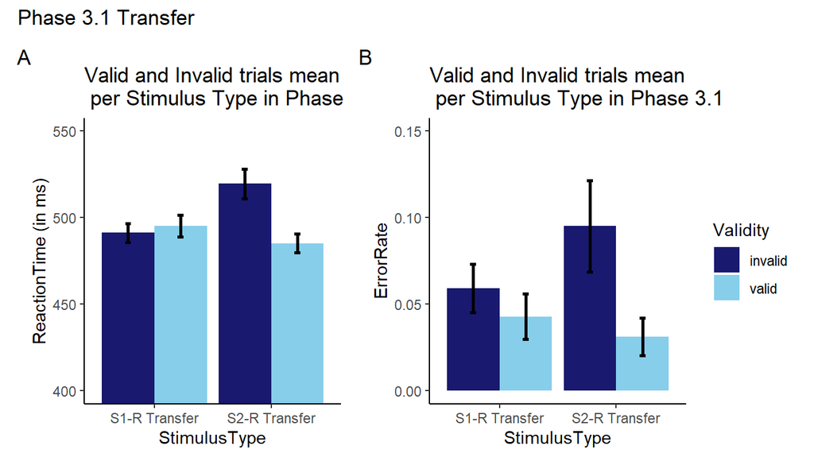

```r
mean3_1er <- summarySEwithin(Exp1_phase3.1, measurevar="ER", withinvars=c("Validity","StimulusType"),
                                 idvar="PROLIFIC_PID", na.rm=FALSE, conf.interval=.95)

inter3.1er <- ggplot(mean3_1er, aes(x=StimulusType, y=ER,fill = Validity))+
  geom_bar(stat = "identity",position = position_dodge())+
  geom_errorbar(aes(ymin = ER - ci, ymax = ER + ci),width = .1, size = 1,position = position_dodge(.9))+
  scale_fill_manual(values = c("midnightblue","skyblue"))+
  coord_cartesian(ylim = c(0,0.15))+
  ggtitle("Valid and Invalid trials mean \n per Stimulus Type in Phase 3.1")+
  theme_classic()+
  ylab("ErrorRate")+
  xlab("StimulusType")+
  theme(text = element_text(size = 20))

Phase31_transfer <- (inter3.1+inter3.1er)+
  plot_annotation(tag_levels = "A", title = "Phase 3.1 Transfer")+
  plot_layout(guides = "collect") & theme_classic()
Phase31_transfer
```

#### Differences per Stimulus Type

1. For S1 the CLeffect in RT is not significant $t = -1.14, p = 0.87$ but in the ER it is significant $t = 1.97, p = 0.026$.

Signs of this could also be spotted in the plot where in ER the trend towards a CL effect for S1 is visible. However it is likely that this is a chance finding and more in depth analysis needs to be done

2. For S2 it is highly significant in both RT and ER as seen in Manipulation Check, point 3.

```r
pander(t.test(data = Exp1_phase3.1, RT~Validity,subset = (StimulusType == "S1-R Transfer"), paired = TRUE, alternative = "greater"), style = 'rmarkdown', caption = "t test showing differences between valid and invalid trials for S1 in Phase 3.1-excluding outliers")
```

t test showing differences between valid and invalid trials for S1 in Phase 3.1-excluding outliers (continued below)

| Test statistic | df | P value | Alternative hypothesis |
| --- | --- | --- | --- |
| -1.143 | 70 | 0.8715 | greater |

| mean of the differences |
| --- |
| -4.102 |

```r
## ER
pander(t.test(data = Exp1_phase3.1, ER~Validity,subset = (StimulusType == "S1-R Transfer"), paired = TRUE, alternative = "greater"), style = 'rmarkdown', caption = "t test (ER) showing differences between valid and invalid trials for S1 in Phase 3.1-excluding outliers")
```

t test (ER) showing differences between valid and invalid trials for S1 in Phase 3.1-excluding outliers (continued below)

| Test statistic | df | P value | Alternative hypothesis |
| --- | --- | --- | --- |
| 1.976 | 70 | 0.02604 * | greater |

| mean of the differences |
| --- |
| 0.0162 |

## 2. Comparing contingency learning effects in Phase 3.2

The transfer effect is tested again in this Phase 3.2 where there is no contingency for S2 and all the stimuli have 50% contingency.

### Reaction Time

Similar to Phase 3.1, the main effect of validity $F = 13.11, p = .001$ and interaction between Validity and StimulusType $F = 9.24, p =.003$ are significant but not the main effect of StimulusType, $F = 1.64, p = .205$. This is now not signfiicant, contrary to what was found in Phase 3.1

```r
Exp1_phase3.2 <- Exp1data %>%
  group_by(PROLIFIC_PID,Validity,Condition) %>%
  filter(Phase == 3.2) %>%
  summarise(ER = mean(ER, na.rm = TRUE),
            RT = mean(RT_io, na.rm = TRUE)) %>%
  rename(StimulusType = Condition)

##ANOVA
anova3.2RT <- ezANOVA(data = Exp1_phase3.2,
                      dv = RT,
                      wid = PROLIFIC_PID,
                      within = .(Validity,StimulusType),
                      detailed = TRUE)
pander(anova_out(anova3.2RT), style = "rmarkdown", caption = "ANOVA:RT for 3.2 transfer")
```

$`--- ANOVA RESULTS ------------------------------------` Effect MSE df1 df2 F p petasq getasq 1 (Intercept) 16569.8745 1 70 4169.53 0.000 0.98 0.98 2 Validity 332.9347 1 70 13.11 0.001 0.16 0.00 3 StimulusType 287.8861 1 70 1.64 0.205 0.02 0.00 4 Validity:StimulusType 485.7169 1 70 9.24 0.003 0.12 0.00

$`--- SPHERICITY TESTS ------------------------------------` [1] “N/A”

$`--- FORMATTED RESULTS ------------------------------------` Effect Text 1 (Intercept) F(1, 70) = 4169.53, p < .001, np2 = .98 2 Validity F(1, 70) = 13.11, p = .001, np2 = .16 3 StimulusType F(1, 70) = 1.64, p = .205, np2 = .02 4 Validity:StimulusType F(1, 70) = 9.24, p = .003, np2 = .12

$`NOTE:` [1] “Reporting unadjusted p-values.”

- **— ANOVA RESULTS ————————————**:

  | Effect | MSE | df1 | df2 | F | p | petasq | getasq |
  | --- | --- | --- | --- | --- | --- | --- | --- |
  | (Intercept) | 16570 | 1 | 70 | 4169.53 | 0.000 | 0.98 | 0.98 |
  | Validity | 332.9 | 1 | 70 | 13.11 | 0.001 | 0.16 | 0.00 |
  | StimulusType | 287.9 | 1 | 70 | 1.64 | 0.205 | 0.02 | 0.00 |
  | Validity:StimulusType | 485.7 | 1 | 70 | 9.24 | 0.003 | 0.12 | 0.00 |

- **— SPHERICITY TESTS ————————————**: N/A
- **— FORMATTED RESULTS ————————————**:

  | Effect | Text |
  | --- | --- |
  | (Intercept) | F(1, 70) = 4169.53, p < .001, np2 = .98 |
  | Validity | F(1, 70) = 13.11, p = .001, np2 = .16 |
  | StimulusType | F(1, 70) = 1.64, p = .205, np2 = .02 |
  | Validity:StimulusType | F(1, 70) = 9.24, p = .003, np2 = .12 |

- **NOTE:**: Reporting unadjusted p-values.

```r
mean3.2 <- summarySEwithin(Exp1_phase3.2, measurevar= "RT", withinvars=c("Validity","StimulusType"),idvar="PROLIFIC_PID", na.rm=FALSE, conf.interval=.95)

inter3.2 <- ggplot(mean3.2, aes(x=StimulusType, y=RT,fill = Validity))+
  geom_bar(stat = "identity",position = position_dodge())+
  geom_errorbar(aes(ymin = RT - ci, ymax = RT + ci),width = .1, size = 1,position = position_dodge(.9))+
  scale_fill_manual(values = c("midnightblue","skyblue"))+
  coord_cartesian(ylim = c(400,550))+
  ggtitle("Valid and Invalid trials mean \n per Stimulus Type in Phase 3.2")+
  theme_classic()+
  ylab("ReactionTime (in ms)")+
  xlab("StimulusType")+
  theme(text = element_text(size = 20))
```

### Error Rate

However, this lack of interaction is not very meaningful as from the graph it can be seen that the direction of CL effect is reversed for S1, hence the lack of interaction cannot be attributed to transfer of associations

```r
# Error Rate
anova32ER <- ezANOVA(data = Exp1_phase3.2,
                   dv = ER,
                   wid = PROLIFIC_PID,
                   within = .(Validity,StimulusType),
                   detailed = TRUE)
pander(anova_out(anova32ER), style = "rmarkdown", caption = "ANOVA:ER for 3.2 transfer")
```

$`--- ANOVA RESULTS ------------------------------------` Effect MSE df1 df2 F p petasq getasq 1 (Intercept) 0.005551531 1 70 128.49 0.000 0.65 0.47 2 Validity 0.002109770 1 70 2.02 0.160 0.03 0.01 3 StimulusType 0.001269171 1 70 0.69 0.408 0.01 0.00 4 Validity:StimulusType 0.002433266 1 70 3.86 0.053 0.05 0.01

$`--- SPHERICITY TESTS ------------------------------------` [1] “N/A”

$`--- FORMATTED RESULTS ------------------------------------` Effect Text 1 (Intercept) F(1, 70) = 128.49, p < .001, np2 = .65 2 Validity F(1, 70) = 2.02, p = .160, np2 = .03 3 StimulusType F(1, 70) = 0.69, p = .408, np2 = .01 4 Validity:StimulusType F(1, 70) = 3.86, p = .053, np2 = .05

$`NOTE:` [1] “Reporting unadjusted p-values.”

- **— ANOVA RESULTS ————————————**:

  | Effect | MSE | df1 | df2 | F | p | petasq | getasq |
  | --- | --- | --- | --- | --- | --- | --- | --- |
  | (Intercept) | 0.005552 | 1 | 70 | 128.49 | 0.000 | 0.65 | 0.47 |
  | Validity | 0.00211 | 1 | 70 | 2.02 | 0.160 | 0.03 | 0.01 |
  | StimulusType | 0.001269 | 1 | 70 | 0.69 | 0.408 | 0.01 | 0.00 |
  | Validity:StimulusType | 0.002433 | 1 | 70 | 3.86 | 0.053 | 0.05 | 0.01 |

- **— SPHERICITY TESTS ————————————**: N/A
- **— FORMATTED RESULTS ————————————**:

  | Effect | Text |
  | --- | --- |
  | (Intercept) | F(1, 70) = 128.49, p < .001, np2 = .65 |
  | Validity | F(1, 70) = 2.02, p = .160, np2 = .03 |
  | StimulusType | F(1, 70) = 0.69, p = .408, np2 = .01 |
  | Validity:StimulusType | F(1, 70) = 3.86, p = .053, np2 = .05 |

- **NOTE:**: Reporting unadjusted p-values.

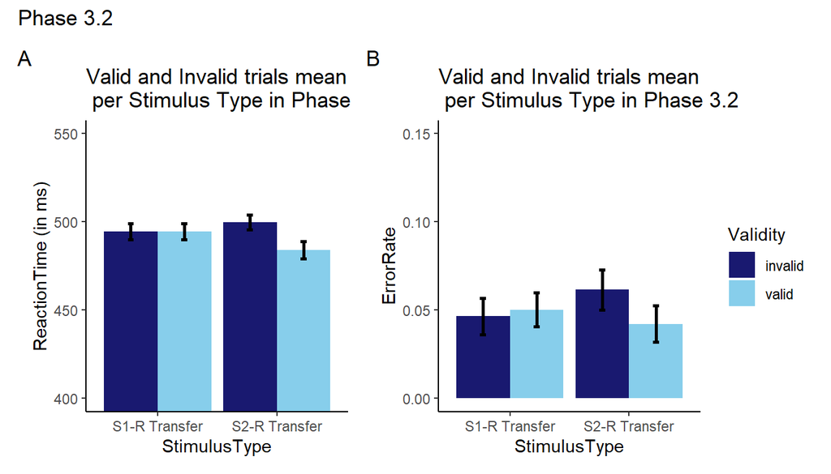

```r
mean3.2er <- summarySEwithin(Exp1_phase3.2, measurevar="ER", withinvars=c("Validity","StimulusType"),                               idvar="PROLIFIC_PID", na.rm=FALSE, conf.interval=.95)


inter3.2er <- ggplot(mean3.2er, aes(x=StimulusType, y=ER,fill = Validity))+
  geom_bar(stat = "identity",position = position_dodge())+
  geom_errorbar(aes(ymin = ER - ci, ymax = ER + ci),width = .1, size = 1,position = position_dodge(.9))+
  scale_fill_manual(values = c("midnightblue","skyblue"))+
  coord_cartesian(ylim = c(0,0.15))+
  ggtitle("Valid and Invalid trials mean \n per Stimulus Type in Phase 3.2")+
  theme_classic()+
  ylab("ErrorRate")+
  xlab("StimulusType")+
  theme(text = element_text(size = 20))


Phase32_transfer <- (inter3.2+inter3.2er)+
  plot_annotation(tag_levels = "A", title = "Phase 3.2")+
  plot_layout(guides = "collect") & theme_classic()

Phase32_transfer
```

#### Differences within stimulus type

The paired t tests results for each stimulus type will reveal the strength of the contingency effect

1. For S1, there is no significant difference in RT as well as ER
2. For S2, both RT and ER show significant differences

```r
## for S1

pander(t.test(data = Exp1_phase3.2, RT~Validity,subset = (StimulusType == "S1-R Transfer"), paired = TRUE, alternative = "greater"), style = 'rmarkdown', caption = "t test, RT showing differences between valid and invalid trials for S1 in Phase 3.2-excluding outliers")
```

t test, RT showing differences between valid and invalid trials for S1 in Phase 3.2-excluding outliers (continued below)

| Test statistic | df | P value | Alternative hypothesis |
| --- | --- | --- | --- |
| -0.03364 | 70 | 0.5134 | greater |

| mean of the differences |
| --- |
| -0.1114 |

```r
pander(t.test(data = Exp1_phase3.2, ER~Validity,subset = (StimulusType == "S1-R Transfer"), paired = TRUE, alternative = "greater"), style = 'rmarkdown', caption = "t test, ER showing differences between valid and invalid trials for S1 in Phase 3.2")
```

t test, ER showing differences between valid and invalid trials for S1 in Phase 3.2 (continued below)

| Test statistic | df | P value | Alternative hypothesis |
| --- | --- | --- | --- |
| -0.4973 | 70 | 0.6897 | greater |

| mean of the differences |
| --- |
| -0.003756 |

```r
## For S2
pander(t.test(data = Exp1_phase3.2, RT~Validity,subset = (StimulusType == "S2-R Transfer"), paired = TRUE, alternative = "greater"), style = 'rmarkdown', caption = "t test, RT showing differences between valid and invalid trials for S1 in Phase 3.2-excluding outliers")
```

t test, RT showing differences between valid and invalid trials for S1 in Phase 3.2-excluding outliers (continued below)

| Test statistic | df | P value | Alternative hypothesis |
| --- | --- | --- | --- |
| 4.542 | 70 | 1.129e-05 * * * | greater |

| mean of the differences |
| --- |
| 15.79 |

```r
pander(t.test(data = Exp1_phase3.2, ER~Validity,subset = (StimulusType == "S2-R Transfer"), paired = TRUE, alternative = "greater"), style = 'rmarkdown', caption = "t test, ER showing differences between valid and invalid trials for S1 in Phase 3.2")
```

t test, ER showing differences between valid and invalid trials for S1 in Phase 3.2 (continued below)

| Test statistic | df | P value | Alternative hypothesis |
| --- | --- | --- | --- |
| 2.285 | 70 | 0.01266 * | greater |

| mean of the differences |
| --- |
| 0.01925 |

> Considering the above aggregated data there does not seem to be transfer between S2 and S1 other than the trend shown in ER in Phase 3.1

### Thoughts

1. It is possible that the contingency relation between S1-S2 became extinct with time, as participants might have unlearnt. As shown by [(Schmidt,Crump & Besner,2007)](https://linkinghub.elsevier.com/retrieve/pii/S1053810009002025) the contingencies can rapidly go extinct and in this case the relation with S2 could have been overwritten with R
2. Possible memory load which was also mentioned in the Schmidt et al., (2007) that there might be more memory resources that makes the encoding/retrieval of the contingency weaker

# Transfer with Awareness Analyses

There were questions at the end of the experiment that tested participants level of awareness of the S-S Associations and the S2-R and S1-R contingencies

The questions were as follows:

1. Do you think “high” was always followed by a particular word? Type “y” for yes, “n” for no, and “k” in case you do not know.
2. What do you think the word is? Type in your answer in the textbox
3. Do you think “even” was always followed by a particular word? Type “y” for yes, “n” for no, and “k” in case you do not know.
4. What do you think the word was? Type your answer
5. Do you think “warm” mostly appeared in a particular colour?. If yes, then type “y”, “n” for no and if you don’t know type “k”.
6. Which colour almost always occurred with “warm”? Type the response key you pressed for that particular colour
7. Do you think “fair” mostly appeared in a particular colour?. If yes, then type “y”, if no then type “n” and if you don’t know type “k”.
8. Which colour almost always occurred with “fair”? Type the response key you pressed for that particular colour
9. Do you think “high” mostly appeared in a particular colour?. If yes, then type “y”, if no then type “n” and if you don’t know type “k”.
10. Which colour almost always occurred with “high”? Type the response key you pressed for that particular colour
11. Do you think “even” mostly appeared in a particular colour?. If yes, then type “y”, if no then type “n” and if you don’t know type “k”.
12. Which colour almost always occurred with “even”? Type the response key you pressed for that particular colour

The Awareness analysis resulted in two more conditions depending on the performance on particular questions. The variables were called as:

1. Awareness : where participants who responded either one of the y/n questions accurately
   - S-S aware: for questions related to Phase 1 (Q1, Q3)
   - S2-R aware: for questions related to Phase 2 (Q5, Q7)
   - S1-R aware: for questions related to Phase 3 (Q9, Q11)
2. Awareness_detailed: where participants who responded either to one of textbox typed answers accurately.
   - S-S aware: for questions related to Phase 1 (Q2, Q4)
   - S2-R aware: for questions related to Phase 2 (Q6, Q8)
   - S1-R aware: for questions related to Phase 3 (Q10, Q12)

These values were then merged to the aggregate files from Phase 3.1 and Phase 3.2 to check for transfer effects

```r
Exp1Aware <- read_csv(here("Data","Exp1AwarenessRecoded.csv"))
Exp1Aware <- Exp1Aware %>%
  mutate(AwareAccuracy = ifelse(recoded == AwareAnswer, 1, 0))

Exp1Aware <- Exp1Aware %>%
  mutate(QuesType = ifelse((Awareness.thisIndex == 0 | Awareness.thisIndex == 2),"S-S Association",
                           ifelse((Awareness.thisIndex == 1 | Awareness.thisIndex == 3),"S-S Association_typed",
                                  ifelse((Awareness.thisIndex == 4 | Awareness.thisIndex == 6), "S2-R",
                                  ifelse((Awareness.thisIndex == 5 | Awareness.thisIndex == 7), "S2-R_typed",
                                  ifelse((Awareness.thisIndex == 8 | Awareness.thisIndex == 10),"S1-R",
                                  ifelse((Awareness.thisIndex == 9 | Awareness.thisIndex == 11),"S1-R_typed",NA)))))))

Exp1Aware %>%
  group_by(QuesType,AwareAccuracy) %>%                drop_na(AwareAccuracy) %>%
  tally() %>%
  kable()
```

| QuesType | AwareAccuracy | n |
| --- | --- | --- |
| S-S Association | 0 | 95 |
| S-S Association | 1 | 46 |
| S-S Association_typed | 0 | 72 |
| S-S Association_typed | 1 | 44 |
| S1-R | 0 | 93 |
| S1-R | 1 | 47 |
| S1-R_typed | 0 | 78 |
| S1-R_typed | 1 | 34 |
| S2-R | 0 | 49 |
| S2-R | 1 | 92 |
| S2-R_typed | 0 | 29 |
| S2-R_typed | 1 | 105 |

```r
Exp1Aware <- Exp1Aware %>%
  mutate(AwareType = ifelse((QuesType == "S-S Association"| QuesType == "S-S Association_typed"),"S-S Awareness",
                           ifelse((QuesType == "S2-R"| QuesType == "S2-R_typed"),"S2-R Awareness",
                                  ifelse((QuesType == "S1-R"| QuesType == "S1-R_typed"),"S1-R Awareness",NA))))


AwareSummary <-Exp1Aware %>%
  group_by(PROLIFIC_PID,AwareType) %>%
  summarise(TotalAcc = sum(AwareAccuracy, na.rm = TRUE))
AwareSummary %>%
  group_by(AwareType,TotalAcc) %>% distinct() %>%
  tally() %>%
  kable(caption = "Summary of Accuracy Scores based on type of Awareness")
```

Summary of Accuracy Scores based on type of Awareness

| AwareType | TotalAcc | n |
| --- | --- | --- |
| S-S Awareness | 0 | 27 |
| S-S Awareness | 1 | 15 |
| S-S Awareness | 2 | 18 |
| S-S Awareness | 3 | 5 |
| S-S Awareness | 4 | 6 |
| S1-R Awareness | 0 | 26 |
| S1-R Awareness | 1 | 17 |
| S1-R Awareness | 2 | 21 |
| S1-R Awareness | 3 | 6 |
| S1-R Awareness | 4 | 1 |
| S2-R Awareness | 0 | 12 |
| S2-R Awareness | 1 | 2 |
| S2-R Awareness | 2 | 14 |
| S2-R Awareness | 3 | 5 |
| S2-R Awareness | 4 | 38 |

```r
AwareSummary <- AwareSummary %>%
  mutate(AwarenessLevel = ifelse(TotalAcc >=2, "Aware","Unaware"))



Exp1_phase3.1_A <- merge(Exp1_phase3.1,AwareSummary, by = "PROLIFIC_PID")
Exp1_phase3.2_A <- merge(Exp1_phase3.2,AwareSummary, by = "PROLIFIC_PID")

##splitting by awareness for 3.1
Exp1_phase3.1_SS <- Exp1_phase3.1_A %>%
  filter(AwareType == "S-S Awareness")

Exp1_phase3.1_S2 <- Exp1_phase3.1_A %>%
  filter(AwareType == "S2-R Awareness")

Exp1_phase3.1_S1 <- Exp1_phase3.1_A %>%
  filter(AwareType == "S1-R Awareness")

#
# #splitting by awareness for 3.2
Exp1_phase3.2_SS <- Exp1_phase3.2_A %>%
  filter(AwareType == "S-S Awareness")

Exp1_phase3.2_S2 <- Exp1_phase3.2_A %>%
  filter(AwareType == "S2-R Awareness")

Exp1_phase3.2_S1 <- Exp1_phase3.2_A %>%
  filter(AwareType == "S1-R Awareness")
```

## Awareness results: ANOVA

## Phase 3.1

### 1. When you have S-2 Awareness

### RT

```r
anova31RT_A_S2 <- ezANOVA(data = Exp1_phase3.1_S2,
                   dv = RT,
                   wid = PROLIFIC_PID,
                   within = .(Validity,StimulusType),
                   between = AwarenessLevel,
                   detailed = TRUE)
pander(anova_out(anova31RT_A_S2), style = "rmarkdown", caption = "ANOVA (RT): for Phase 3.1 across stimulus type")
```

$`--- ANOVA RESULTS ------------------------------------` Effect MSE df1 df2 F p petasq 1 (Intercept) 18411.9412 1 69 3823.02 0.000 0.98 2 AwarenessLevel 18411.9412 1 69 0.77 0.382 0.01 3 Validity 722.1124 1 69 22.47 0.000 0.25 4 StimulusType 922.1871 1 69 6.38 0.014 0.08 5 AwarenessLevel:Validity 722.1124 1 69 0.37 0.546 0.01 6 AwarenessLevel:StimulusType 922.1871 1 69 1.43 0.235 0.02 7 Validity:StimulusType 662.9161 1 69 39.56 0.000 0.36 8 AwarenessLevel:Validity:StimulusType 662.9161 1 69 0.08 0.783 0.00 getasq 1 0.98 2 0.01 3 0.01 4 0.00 5 0.00 6 0.00 7 0.02 8 0.00

$`--- SPHERICITY TESTS ------------------------------------` [1] “N/A”

$`--- FORMATTED RESULTS ------------------------------------` Effect Text 1 (Intercept) F(1, 69) = 3823.02, p < .001, np2 = .98 2 AwarenessLevel F(1, 69) = 0.77, p = .382, np2 = .01 3 Validity F(1, 69) = 22.47, p < .001, np2 = .25 4 StimulusType F(1, 69) = 6.38, p = .014, np2 = .08 5 AwarenessLevel:Validity F(1, 69) = 0.37, p = .546, np2 = .01 6 AwarenessLevel:StimulusType F(1, 69) = 1.43, p = .235, np2 = .02 7 Validity:StimulusType F(1, 69) = 39.56, p < .001, np2 = .36 8 AwarenessLevel:Validity:StimulusType F(1, 69) = 0.08, p = .783, np2 < .01

$`NOTE:` [1] “Reporting unadjusted p-values.”

- **— ANOVA RESULTS ————————————**:

  Table continues below

  | Effect | MSE | df1 | df2 | F | p |
  | --- | --- | --- | --- | --- | --- |
  | (Intercept) | 18412 | 1 | 69 | 3823.02 | 0.000 |
  | AwarenessLevel | 18412 | 1 | 69 | 0.77 | 0.382 |
  | Validity | 722.1 | 1 | 69 | 22.47 | 0.000 |
  | StimulusType | 922.2 | 1 | 69 | 6.38 | 0.014 |
  | AwarenessLevel:Validity | 722.1 | 1 | 69 | 0.37 | 0.546 |
  | AwarenessLevel:StimulusType | 922.2 | 1 | 69 | 1.43 | 0.235 |
  | Validity:StimulusType | 662.9 | 1 | 69 | 39.56 | 0.000 |
  | AwarenessLevel:Validity:StimulusType | 662.9 | 1 | 69 | 0.08 | 0.783 |

  | petasq | getasq |
  | --- | --- |
  | 0.98 | 0.98 |
  | 0.01 | 0.01 |
  | 0.25 | 0.01 |
  | 0.08 | 0.00 |
  | 0.01 | 0.00 |
  | 0.02 | 0.00 |
  | 0.36 | 0.02 |
  | 0.00 | 0.00 |

- **— SPHERICITY TESTS ————————————**: N/A
- **— FORMATTED RESULTS ————————————**:

  | Effect | Text |
  | --- | --- |
  | (Intercept) | F(1, 69) = 3823.02, p < .001, np2 = .98 |
  | AwarenessLevel | F(1, 69) = 0.77, p = .382, np2 = .01 |
  | Validity | F(1, 69) = 22.47, p < .001, np2 = .25 |
  | StimulusType | F(1, 69) = 6.38, p = .014, np2 = .08 |
  | AwarenessLevel:Validity | F(1, 69) = 0.37, p = .546, np2 = .01 |
  | AwarenessLevel:StimulusType | F(1, 69) = 1.43, p = .235, np2 = .02 |
  | Validity:StimulusType | F(1, 69) = 39.56, p < .001, np2 = .36 |
  | AwarenessLevel:Validity:StimulusType | F(1, 69) = 0.08, p = .783, np2 < .01 |

- **NOTE:**: Reporting unadjusted p-values.

```r
S2_31 <- ggplot(Exp1_phase3.1_S2, aes(x=StimulusType, y=RT,fill = Validity))+
  geom_bar(stat = "summary", fun = "mean",position = position_dodge())+
  #geom_errorbar(aes(ymin = RT - ci, ymax = RT + ci),width = .1, size = 1,position = position_dodge(.9))+
  scale_fill_manual(values = c("midnightblue","skyblue"))+
  coord_cartesian(ylim = c(400,550))+
  ylab("ReactionTime (in ms)")+
  xlab("StimulusType")+
  facet_grid(.~AwarenessLevel)+
  labs(subtitle = "Awareness of \n S2-R Association")+
  theme(text = element_text(size = 20), axis.text.x = element_text(angle = 90))
```

### ER

```r
anova31ER_A_S2 <- ezANOVA(data = Exp1_phase3.1_S2,
                   dv = ER,
                   wid = PROLIFIC_PID,
                   within = .(Validity,StimulusType),
                   between = .(AwarenessLevel),
                   detailed = TRUE)
pander(anova_out(anova31ER_A_S2), style = "rmarkdown", caption = "ANOVA (ER): for Phase 3.1 across stimulus type")
```

$`--- ANOVA RESULTS ------------------------------------` Effect MSE df1 df2 F p petasq 1 (Intercept) 0.011493397 1 69 80.59 0.000 0.54 2 AwarenessLevel 0.011493397 1 69 0.13 0.721 0.00 3 Validity 0.005760153 1 69 19.73 0.000 0.22 4 StimulusType 0.005045609 1 69 2.06 0.156 0.03 5 AwarenessLevel:Validity 0.005760153 1 69 0.02 0.886 0.00 6 AwarenessLevel:StimulusType 0.005045609 1 69 1.18 0.281 0.02 7 Validity:StimulusType 0.005205948 1 69 7.73 0.007 0.10 8 AwarenessLevel:Validity:StimulusType 0.005205948 1 69 0.46 0.501 0.01 getasq 1 0.33 2 0.00 3 0.06 4 0.01 5 0.00 6 0.00 7 0.02 8 0.00

$`--- SPHERICITY TESTS ------------------------------------` [1] “N/A”

$`--- FORMATTED RESULTS ------------------------------------` Effect Text 1 (Intercept) F(1, 69) = 80.59, p < .001, np2 = .54 2 AwarenessLevel F(1, 69) = 0.13, p = .721, np2 < .01 3 Validity F(1, 69) = 19.73, p < .001, np2 = .22 4 StimulusType F(1, 69) = 2.06, p = .156, np2 = .03 5 AwarenessLevel:Validity F(1, 69) = 0.02, p = .886, np2 < .01 6 AwarenessLevel:StimulusType F(1, 69) = 1.18, p = .281, np2 = .02 7 Validity:StimulusType F(1, 69) = 7.73, p = .007, np2 = .10 8 AwarenessLevel:Validity:StimulusType F(1, 69) = 0.46, p = .501, np2 = .01

$`NOTE:` [1] “Reporting unadjusted p-values.”

- **— ANOVA RESULTS ————————————**:

  Table continues below

  | Effect | MSE | df1 | df2 | F | p |
  | --- | --- | --- | --- | --- | --- |
  | (Intercept) | 0.01149 | 1 | 69 | 80.59 | 0.000 |
  | AwarenessLevel | 0.01149 | 1 | 69 | 0.13 | 0.721 |
  | Validity | 0.00576 | 1 | 69 | 19.73 | 0.000 |
  | StimulusType | 0.005046 | 1 | 69 | 2.06 | 0.156 |
  | AwarenessLevel:Validity | 0.00576 | 1 | 69 | 0.02 | 0.886 |
  | AwarenessLevel:StimulusType | 0.005046 | 1 | 69 | 1.18 | 0.281 |
  | Validity:StimulusType | 0.005206 | 1 | 69 | 7.73 | 0.007 |
  | AwarenessLevel:Validity:StimulusType | 0.005206 | 1 | 69 | 0.46 | 0.501 |

  | petasq | getasq |
  | --- | --- |
  | 0.54 | 0.33 |
  | 0.00 | 0.00 |
  | 0.22 | 0.06 |
  | 0.03 | 0.01 |
  | 0.00 | 0.00 |
  | 0.02 | 0.00 |
  | 0.10 | 0.02 |
  | 0.01 | 0.00 |

- **— SPHERICITY TESTS ————————————**: N/A
- **— FORMATTED RESULTS ————————————**:

  | Effect | Text |
  | --- | --- |
  | (Intercept) | F(1, 69) = 80.59, p < .001, np2 = .54 |
  | AwarenessLevel | F(1, 69) = 0.13, p = .721, np2 < .01 |
  | Validity | F(1, 69) = 19.73, p < .001, np2 = .22 |
  | StimulusType | F(1, 69) = 2.06, p = .156, np2 = .03 |
  | AwarenessLevel:Validity | F(1, 69) = 0.02, p = .886, np2 < .01 |
  | AwarenessLevel:StimulusType | F(1, 69) = 1.18, p = .281, np2 = .02 |
  | Validity:StimulusType | F(1, 69) = 7.73, p = .007, np2 = .10 |
  | AwarenessLevel:Validity:StimulusType | F(1, 69) = 0.46, p = .501, np2 = .01 |

- **NOTE:**: Reporting unadjusted p-values.

```r
S2_31_er <- ggplot(Exp1_phase3.1_S2, aes(x=StimulusType, y=ER,fill = Validity))+
  geom_bar(stat = "summary", fun = "mean",position = position_dodge())+
  #geom_errorbar(aes(ymin = RT - ci, ymax = RT + ci),width = .1, size = 1,position = position_dodge(.9))+
  scale_fill_manual(values = c("midnightblue","skyblue"))+
  coord_cartesian(ylim = c(0,0.15))+
  ylab("Error Rate")+
  xlab("StimulusType")+
  facet_grid(.~AwarenessLevel)+
  labs(subtitle = "awareness of \n S2 association")+
  theme(text = element_text(size = 20), axis.text.x = element_text(angle = 15))
```

### 2. When you have S-S Awareness

### RT

```r
anova31RT_A_SS <- ezANOVA(data = Exp1_phase3.1_SS,
                   dv = RT,
                   wid = PROLIFIC_PID,
                   within = .(Validity,StimulusType),
                   between = .(AwarenessLevel),
                   detailed = TRUE)
pander(anova_out(anova31RT_A_SS), style = "rmarkdown", caption = "ANOVA (RT): for Phase 3.1 across stimulus type based on SS AWareness")
```

$`--- ANOVA RESULTS ------------------------------------` Effect MSE df1 df2 F p petasq 1 (Intercept) 18586.8325 1 69 3787.04 0.000 0.98 2 AwarenessLevel 18586.8325 1 69 0.12 0.732 0.00 3 Validity 718.7597 1 69 22.58 0.000 0.25 4 StimulusType 930.4710 1 69 6.33 0.014 0.08 5 AwarenessLevel:Validity 718.7597 1 69 0.69 0.409 0.01 6 AwarenessLevel:StimulusType 930.4710 1 69 0.81 0.372 0.01 7 Validity:StimulusType 663.4511 1 69 39.53 0.000 0.36 8 AwarenessLevel:Validity:StimulusType 663.4511 1 69 0.02 0.885 0.00 getasq 1 0.98 2 0.00 3 0.01 4 0.00 5 0.00 6 0.00 7 0.02 8 0.00

$`--- SPHERICITY TESTS ------------------------------------` [1] “N/A”

$`--- FORMATTED RESULTS ------------------------------------` Effect Text 1 (Intercept) F(1, 69) = 3787.04, p < .001, np2 = .98 2 AwarenessLevel F(1, 69) = 0.12, p = .732, np2 < .01 3 Validity F(1, 69) = 22.58, p < .001, np2 = .25 4 StimulusType F(1, 69) = 6.33, p = .014, np2 = .08 5 AwarenessLevel:Validity F(1, 69) = 0.69, p = .409, np2 = .01 6 AwarenessLevel:StimulusType F(1, 69) = 0.81, p = .372, np2 = .01 7 Validity:StimulusType F(1, 69) = 39.53, p < .001, np2 = .36 8 AwarenessLevel:Validity:StimulusType F(1, 69) = 0.02, p = .885, np2 < .01

$`NOTE:` [1] “Reporting unadjusted p-values.”

- **— ANOVA RESULTS ————————————**:

  Table continues below

  | Effect | MSE | df1 | df2 | F | p |
  | --- | --- | --- | --- | --- | --- |
  | (Intercept) | 18587 | 1 | 69 | 3787.04 | 0.000 |
  | AwarenessLevel | 18587 | 1 | 69 | 0.12 | 0.732 |
  | Validity | 718.8 | 1 | 69 | 22.58 | 0.000 |
  | StimulusType | 930.5 | 1 | 69 | 6.33 | 0.014 |
  | AwarenessLevel:Validity | 718.8 | 1 | 69 | 0.69 | 0.409 |
  | AwarenessLevel:StimulusType | 930.5 | 1 | 69 | 0.81 | 0.372 |
  | Validity:StimulusType | 663.5 | 1 | 69 | 39.53 | 0.000 |
  | AwarenessLevel:Validity:StimulusType | 663.5 | 1 | 69 | 0.02 | 0.885 |

  | petasq | getasq |
  | --- | --- |
  | 0.98 | 0.98 |
  | 0.00 | 0.00 |
  | 0.25 | 0.01 |
  | 0.08 | 0.00 |
  | 0.01 | 0.00 |
  | 0.01 | 0.00 |
  | 0.36 | 0.02 |
  | 0.00 | 0.00 |

- **— SPHERICITY TESTS ————————————**: N/A
- **— FORMATTED RESULTS ————————————**:

  | Effect | Text |
  | --- | --- |
  | (Intercept) | F(1, 69) = 3787.04, p < .001, np2 = .98 |
  | AwarenessLevel | F(1, 69) = 0.12, p = .732, np2 < .01 |
  | Validity | F(1, 69) = 22.58, p < .001, np2 = .25 |
  | StimulusType | F(1, 69) = 6.33, p = .014, np2 = .08 |
  | AwarenessLevel:Validity | F(1, 69) = 0.69, p = .409, np2 = .01 |
  | AwarenessLevel:StimulusType | F(1, 69) = 0.81, p = .372, np2 = .01 |
  | Validity:StimulusType | F(1, 69) = 39.53, p < .001, np2 = .36 |
  | AwarenessLevel:Validity:StimulusType | F(1, 69) = 0.02, p = .885, np2 < .01 |

- **NOTE:**: Reporting unadjusted p-values.

```r
SS_31 <- ggplot(Exp1_phase3.1_SS, aes(x=StimulusType, y=RT,fill = Validity))+
  geom_bar(stat = "summary", fun = "mean",position = position_dodge())+
  #geom_errorbar(aes(ymin = RT - ci, ymax = RT + ci),width = .1, size = 1,position = position_dodge(.9))+
  scale_fill_manual(values = c("midnightblue","skyblue"))+
  coord_cartesian(ylim = c(400,550))+
  ylab("ReactionTime (in ms)")+
  xlab("StimulusType")+
  facet_grid(.~AwarenessLevel)+
  labs(subtitle = "Awareness of \n S-S Association")+
  theme(text = element_text(size = 20), axis.text.x = element_text(angle = 90))
```

### ER

```r
anova31ER_A_SS <- ezANOVA(data = Exp1_phase3.1_SS,
                   dv = ER,
                   wid = PROLIFIC_PID,
                   within = .(Validity,StimulusType),
                   between = .(AwarenessLevel),
                   detailed = TRUE)
pander(anova_out(anova31ER_A_SS), style = "rmarkdown", caption = "ANOVA (ER): for Phase 3.1 across stimulus type")
```

$`--- ANOVA RESULTS ------------------------------------` Effect MSE df1 df2 F p petasq 1 (Intercept) 0.011512192 1 69 80.46 0.000 0.54 2 AwarenessLevel 0.011512192 1 69 0.02 0.899 0.00 3 Validity 0.005729441 1 69 19.84 0.000 0.22 4 StimulusType 0.005131007 1 69 2.03 0.159 0.03 5 AwarenessLevel:Validity 0.005729441 1 69 0.39 0.534 0.01 6 AwarenessLevel:StimulusType 0.005131007 1 69 0.01 0.914 0.00 7 Validity:StimulusType 0.005240214 1 69 7.68 0.007 0.10 8 AwarenessLevel:Validity:StimulusType 0.005240214 1 69 0.00 0.958 0.00 getasq 1 0.33 2 0.00 3 0.06 4 0.01 5 0.00 6 0.00 7 0.02 8 0.00

$`--- SPHERICITY TESTS ------------------------------------` [1] “N/A”

$`--- FORMATTED RESULTS ------------------------------------` Effect Text 1 (Intercept) F(1, 69) = 80.46, p < .001, np2 = .54 2 AwarenessLevel F(1, 69) = 0.02, p = .899, np2 < .01 3 Validity F(1, 69) = 19.84, p < .001, np2 = .22 4 StimulusType F(1, 69) = 2.03, p = .159, np2 = .03 5 AwarenessLevel:Validity F(1, 69) = 0.39, p = .534, np2 = .01 6 AwarenessLevel:StimulusType F(1, 69) = 0.01, p = .914, np2 < .01 7 Validity:StimulusType F(1, 69) = 7.68, p = .007, np2 = .10 8 AwarenessLevel:Validity:StimulusType F(1, 69) = 0.00, p = .958, np2 < .01

$`NOTE:` [1] “Reporting unadjusted p-values.”

- **— ANOVA RESULTS ————————————**:

  Table continues below

  | Effect | MSE | df1 | df2 | F | p |
  | --- | --- | --- | --- | --- | --- |
  | (Intercept) | 0.01151 | 1 | 69 | 80.46 | 0.000 |
  | AwarenessLevel | 0.01151 | 1 | 69 | 0.02 | 0.899 |
  | Validity | 0.005729 | 1 | 69 | 19.84 | 0.000 |
  | StimulusType | 0.005131 | 1 | 69 | 2.03 | 0.159 |
  | AwarenessLevel:Validity | 0.005729 | 1 | 69 | 0.39 | 0.534 |
  | AwarenessLevel:StimulusType | 0.005131 | 1 | 69 | 0.01 | 0.914 |
  | Validity:StimulusType | 0.00524 | 1 | 69 | 7.68 | 0.007 |
  | AwarenessLevel:Validity:StimulusType | 0.00524 | 1 | 69 | 0.00 | 0.958 |

  | petasq | getasq |
  | --- | --- |
  | 0.54 | 0.33 |
  | 0.00 | 0.00 |
  | 0.22 | 0.06 |
  | 0.03 | 0.01 |
  | 0.01 | 0.00 |
  | 0.00 | 0.00 |
  | 0.10 | 0.02 |
  | 0.00 | 0.00 |

- **— SPHERICITY TESTS ————————————**: N/A
- **— FORMATTED RESULTS ————————————**:

  | Effect | Text |
  | --- | --- |
  | (Intercept) | F(1, 69) = 80.46, p < .001, np2 = .54 |
  | AwarenessLevel | F(1, 69) = 0.02, p = .899, np2 < .01 |
  | Validity | F(1, 69) = 19.84, p < .001, np2 = .22 |
  | StimulusType | F(1, 69) = 2.03, p = .159, np2 = .03 |
  | AwarenessLevel:Validity | F(1, 69) = 0.39, p = .534, np2 = .01 |
  | AwarenessLevel:StimulusType | F(1, 69) = 0.01, p = .914, np2 < .01 |
  | Validity:StimulusType | F(1, 69) = 7.68, p = .007, np2 = .10 |
  | AwarenessLevel:Validity:StimulusType | F(1, 69) = 0.00, p = .958, np2 < .01 |

- **NOTE:**: Reporting unadjusted p-values.

```r
SS_31_er <- ggplot(Exp1_phase3.1_SS, aes(x=StimulusType, y=ER,fill = Validity))+
  geom_bar(stat = "summary", fun = "mean",position = position_dodge())+
  #geom_errorbar(aes(ymin = RT - ci, ymax = RT + ci),width = .1, size = 1,position = position_dodge(.9))+
  scale_fill_manual(values = c("midnightblue","skyblue"))+
  coord_cartesian(ylim = c(0,0.15))+
  ylab("Error Rate")+
  xlab("StimulusType")+
  facet_grid(.~AwarenessLevel)+
  labs(subtitle = "awareness of \n SS association")+
  theme(text = element_text(size = 20), axis.text.x = element_text(angle = 15))
```

### When you show an awareness transfer to S1

### RT

```r
anova31RT_A_S1 <- ezANOVA(data = Exp1_phase3.1_S1,
                   dv = RT,
                   wid = PROLIFIC_PID,
                   within = .(Validity,StimulusType),
                   between = .(AwarenessLevel),
                   detailed = TRUE)
pander(anova_out(anova31RT_A_S1), style = "rmarkdown", caption = "ANOVA (RT): for Phase 3.1 across stimulus type based on S1 AWareness")
```

$`--- ANOVA RESULTS ------------------------------------` Effect MSE df1 df2 F p petasq 1 (Intercept) 18534.8904 1 69 3797.66 0.000 0.98 2 AwarenessLevel 18534.8904 1 69 0.31 0.578 0.00 3 Validity 724.4619 1 69 22.40 0.000 0.25 4 StimulusType 940.1116 1 69 6.26 0.015 0.08 5 AwarenessLevel:Validity 724.4619 1 69 0.14 0.707 0.00 6 AwarenessLevel:StimulusType 940.1116 1 69 0.09 0.765 0.00 7 Validity:StimulusType 660.8842 1 69 39.68 0.000 0.37 8 AwarenessLevel:Validity:StimulusType 660.8842 1 69 0.29 0.593 0.00 getasq 1 0.98 2 0.00 3 0.01 4 0.00 5 0.00 6 0.00 7 0.02 8 0.00

$`--- SPHERICITY TESTS ------------------------------------` [1] “N/A”

$`--- FORMATTED RESULTS ------------------------------------` Effect Text 1 (Intercept) F(1, 69) = 3797.66, p < .001, np2 = .98 2 AwarenessLevel F(1, 69) = 0.31, p = .578, np2 < .01 3 Validity F(1, 69) = 22.40, p < .001, np2 = .25 4 StimulusType F(1, 69) = 6.26, p = .015, np2 = .08 5 AwarenessLevel:Validity F(1, 69) = 0.14, p = .707, np2 < .01 6 AwarenessLevel:StimulusType F(1, 69) = 0.09, p = .765, np2 < .01 7 Validity:StimulusType F(1, 69) = 39.68, p < .001, np2 = .37 8 AwarenessLevel:Validity:StimulusType F(1, 69) = 0.29, p = .593, np2 < .01

$`NOTE:` [1] “Reporting unadjusted p-values.”

- **— ANOVA RESULTS ————————————**:

  Table continues below

  | Effect | MSE | df1 | df2 | F | p |
  | --- | --- | --- | --- | --- | --- |
  | (Intercept) | 18535 | 1 | 69 | 3797.66 | 0.000 |
  | AwarenessLevel | 18535 | 1 | 69 | 0.31 | 0.578 |
  | Validity | 724.5 | 1 | 69 | 22.40 | 0.000 |
  | StimulusType | 940.1 | 1 | 69 | 6.26 | 0.015 |
  | AwarenessLevel:Validity | 724.5 | 1 | 69 | 0.14 | 0.707 |
  | AwarenessLevel:StimulusType | 940.1 | 1 | 69 | 0.09 | 0.765 |
  | Validity:StimulusType | 660.9 | 1 | 69 | 39.68 | 0.000 |
  | AwarenessLevel:Validity:StimulusType | 660.9 | 1 | 69 | 0.29 | 0.593 |

  | petasq | getasq |
  | --- | --- |
  | 0.98 | 0.98 |
  | 0.00 | 0.00 |
  | 0.25 | 0.01 |
  | 0.08 | 0.00 |
  | 0.00 | 0.00 |
  | 0.00 | 0.00 |
  | 0.37 | 0.02 |
  | 0.00 | 0.00 |

- **— SPHERICITY TESTS ————————————**: N/A
- **— FORMATTED RESULTS ————————————**:

  | Effect | Text |
  | --- | --- |
  | (Intercept) | F(1, 69) = 3797.66, p < .001, np2 = .98 |
  | AwarenessLevel | F(1, 69) = 0.31, p = .578, np2 < .01 |
  | Validity | F(1, 69) = 22.40, p < .001, np2 = .25 |
  | StimulusType | F(1, 69) = 6.26, p = .015, np2 = .08 |
  | AwarenessLevel:Validity | F(1, 69) = 0.14, p = .707, np2 < .01 |
  | AwarenessLevel:StimulusType | F(1, 69) = 0.09, p = .765, np2 < .01 |
  | Validity:StimulusType | F(1, 69) = 39.68, p < .001, np2 = .37 |
  | AwarenessLevel:Validity:StimulusType | F(1, 69) = 0.29, p = .593, np2 < .01 |

- **NOTE:**: Reporting unadjusted p-values.

```r
S1_31 <- ggplot(Exp1_phase3.1_S1, aes(x=StimulusType, y=RT,fill = Validity))+
  geom_bar(stat = "summary", fun = "mean",position = position_dodge())+
  #geom_errorbar(aes(ymin = RT - ci, ymax = RT + ci),width = .1, size = 1,position = position_dodge(.9))+
  scale_fill_manual(values = c("midnightblue","skyblue"))+
  coord_cartesian(ylim = c(400,550))+
  ylab("ReactionTime (in ms)")+
  xlab("StimulusType")+
  facet_grid(.~AwarenessLevel)+
  labs(subtitle = "Awareness of \n S1-R Association")+
  theme(text = element_text(size = 20), axis.text.x = element_text(angle = 90))
```

### ER

```r
anova31ER_A_S1 <- ezANOVA(data = Exp1_phase3.1_S1,
                   dv = ER,
                   wid = PROLIFIC_PID,
                   within = .(Validity,StimulusType),
                   between = .(AwarenessLevel),
                   detailed = TRUE)
pander(anova_out(anova31ER_A_S1), style = "rmarkdown", caption = "ANOVA (ER): for Phase 3.1 across stimulus type")
```

$`--- ANOVA RESULTS ------------------------------------` Effect MSE df1 df2 F p petasq 1 (Intercept) 0.011436972 1 69 80.99 0.000 0.54 2 AwarenessLevel 0.011436972 1 69 0.47 0.495 0.01 3 Validity 0.005726064 1 69 19.85 0.000 0.22 4 StimulusType 0.005125131 1 69 2.03 0.159 0.03 5 AwarenessLevel:Validity 0.005726064 1 69 0.43 0.513 0.01 6 AwarenessLevel:StimulusType 0.005125131 1 69 0.09 0.764 0.00 7 Validity:StimulusType 0.005240364 1 69 7.68 0.007 0.10 8 AwarenessLevel:Validity:StimulusType 0.005240364 1 69 0.00 0.978 0.00 getasq 1 0.33 2 0.00 3 0.06 4 0.01 5 0.00 6 0.00 7 0.02 8 0.00

$`--- SPHERICITY TESTS ------------------------------------` [1] “N/A”

$`--- FORMATTED RESULTS ------------------------------------` Effect Text 1 (Intercept) F(1, 69) = 80.99, p < .001, np2 = .54 2 AwarenessLevel F(1, 69) = 0.47, p = .495, np2 = .01 3 Validity F(1, 69) = 19.85, p < .001, np2 = .22 4 StimulusType F(1, 69) = 2.03, p = .159, np2 = .03 5 AwarenessLevel:Validity F(1, 69) = 0.43, p = .513, np2 = .01 6 AwarenessLevel:StimulusType F(1, 69) = 0.09, p = .764, np2 < .01 7 Validity:StimulusType F(1, 69) = 7.68, p = .007, np2 = .10 8 AwarenessLevel:Validity:StimulusType F(1, 69) = 0.00, p = .978, np2 < .01

$`NOTE:` [1] “Reporting unadjusted p-values.”

- **— ANOVA RESULTS ————————————**:

  Table continues below

  | Effect | MSE | df1 | df2 | F | p |
  | --- | --- | --- | --- | --- | --- |
  | (Intercept) | 0.01144 | 1 | 69 | 80.99 | 0.000 |
  | AwarenessLevel | 0.01144 | 1 | 69 | 0.47 | 0.495 |
  | Validity | 0.005726 | 1 | 69 | 19.85 | 0.000 |
  | StimulusType | 0.005125 | 1 | 69 | 2.03 | 0.159 |
  | AwarenessLevel:Validity | 0.005726 | 1 | 69 | 0.43 | 0.513 |
  | AwarenessLevel:StimulusType | 0.005125 | 1 | 69 | 0.09 | 0.764 |
  | Validity:StimulusType | 0.00524 | 1 | 69 | 7.68 | 0.007 |
  | AwarenessLevel:Validity:StimulusType | 0.00524 | 1 | 69 | 0.00 | 0.978 |

  | petasq | getasq |
  | --- | --- |
  | 0.54 | 0.33 |
  | 0.01 | 0.00 |
  | 0.22 | 0.06 |
  | 0.03 | 0.01 |
  | 0.01 | 0.00 |
  | 0.00 | 0.00 |
  | 0.10 | 0.02 |
  | 0.00 | 0.00 |

- **— SPHERICITY TESTS ————————————**: N/A
- **— FORMATTED RESULTS ————————————**:

  | Effect | Text |
  | --- | --- |
  | (Intercept) | F(1, 69) = 80.99, p < .001, np2 = .54 |
  | AwarenessLevel | F(1, 69) = 0.47, p = .495, np2 = .01 |
  | Validity | F(1, 69) = 19.85, p < .001, np2 = .22 |
  | StimulusType | F(1, 69) = 2.03, p = .159, np2 = .03 |
  | AwarenessLevel:Validity | F(1, 69) = 0.43, p = .513, np2 = .01 |
  | AwarenessLevel:StimulusType | F(1, 69) = 0.09, p = .764, np2 < .01 |
  | Validity:StimulusType | F(1, 69) = 7.68, p = .007, np2 = .10 |
  | AwarenessLevel:Validity:StimulusType | F(1, 69) = 0.00, p = .978, np2 < .01 |

- **NOTE:**: Reporting unadjusted p-values.

```r
S1_31_er <- ggplot(Exp1_phase3.1_S1, aes(x=StimulusType, y=ER,fill = Validity))+
  geom_bar(stat = "summary", fun = "mean",position = position_dodge())+
  #geom_errorbar(aes(ymin = RT - ci, ymax = RT + ci),width = .1, size = 1,position = position_dodge(.9))+
  scale_fill_manual(values = c("midnightblue","skyblue"))+
  coord_cartesian(ylim = c(0,0.15))+
  ylab("Error Rate")+
  xlab("StimulusType")+
  facet_grid(.~AwarenessLevel)+
  labs(subtitle = "awareness of \n S1-R association")+
  theme(text = element_text(size = 20), axis.text.x = element_text(angle = 15))
```

### Phase 1 Plots

1. RT

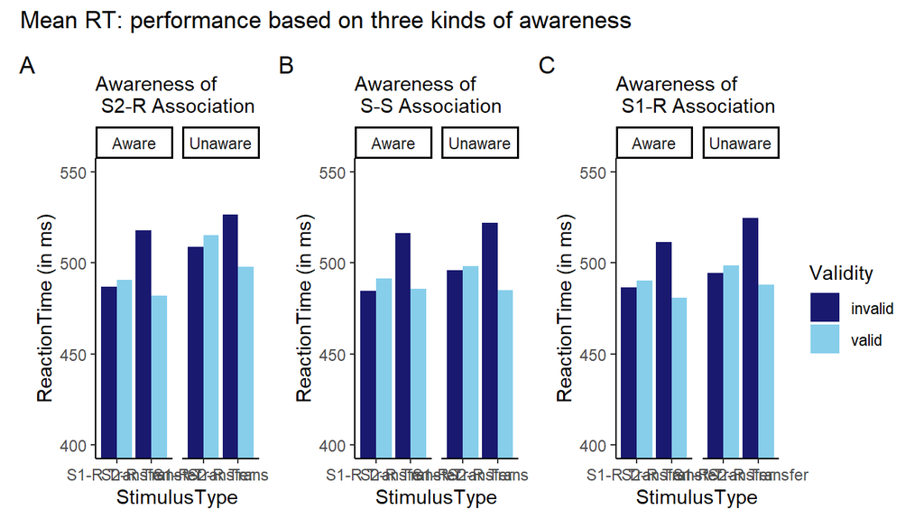

```r
RT3A <- (S2_31 + SS_31 + S1_31)+
  plot_annotation(tag_levels = "A", title = "Mean RT: performance based on three kinds of awareness")+
  plot_layout(guides = "collect")&theme_classic()
RT3A
```

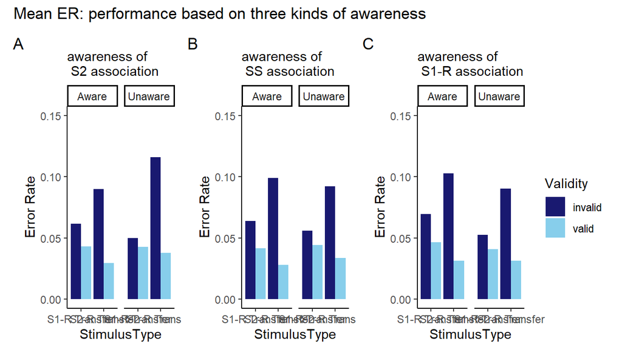

```r
ER3A <- (S2_31_er + SS_31_er + S1_31_er)+
  plot_annotation(tag_levels = "A", title = "Mean ER: performance based on three kinds of awareness")+
  plot_layout(guides = "collect")&theme_classic()
ER3A
```

## Phase 3.2

### RT

```r
anova32RT_A_S2 <- ezANOVA(data = Exp1_phase3.2_S2,
                   dv = RT,
                   wid = PROLIFIC_PID,
                   within = .(Validity,StimulusType),
                   between = .(AwarenessLevel),
                   detailed = TRUE)
pander(anova_out(anova32RT_A_S2), style = "rmarkdown", caption = "ANOVA (RT): for Phase 3.1 across stimulus type")
```

$`--- ANOVA RESULTS ------------------------------------` Effect MSE df1 df2 F p petasq 1 (Intercept) 16530.2214 1 69 4179.53 0.000 0.98 2 AwarenessLevel 16530.2214 1 69 1.17 0.284 0.02 3 Validity 305.6807 1 69 14.28 0.000 0.17 4 StimulusType 291.7200 1 69 1.62 0.208 0.02 5 AwarenessLevel:Validity 305.6807 1 69 7.24 0.009 0.09 6 AwarenessLevel:StimulusType 291.7200 1 69 0.08 0.778 0.00 7 Validity:StimulusType 489.3776 1 69 9.18 0.003 0.12 8 AwarenessLevel:Validity:StimulusType 489.3776 1 69 0.48 0.492 0.01 getasq 1 0.98 2 0.02 3 0.00 4 0.00 5 0.00 6 0.00 7 0.00 8 0.00

$`--- SPHERICITY TESTS ------------------------------------` [1] “N/A”

$`--- FORMATTED RESULTS ------------------------------------` Effect Text 1 (Intercept) F(1, 69) = 4179.53, p < .001, np2 = .98 2 AwarenessLevel F(1, 69) = 1.17, p = .284, np2 = .02 3 Validity F(1, 69) = 14.28, p < .001, np2 = .17 4 StimulusType F(1, 69) = 1.62, p = .208, np2 = .02 5 AwarenessLevel:Validity F(1, 69) = 7.24, p = .009, np2 = .09 6 AwarenessLevel:StimulusType F(1, 69) = 0.08, p = .778, np2 < .01 7 Validity:StimulusType F(1, 69) = 9.18, p = .003, np2 = .12 8 AwarenessLevel:Validity:StimulusType F(1, 69) = 0.48, p = .492, np2 = .01

$`NOTE:` [1] “Reporting unadjusted p-values.”

- **— ANOVA RESULTS ————————————**:

  Table continues below

  | Effect | MSE | df1 | df2 | F | p |
  | --- | --- | --- | --- | --- | --- |
  | (Intercept) | 16530 | 1 | 69 | 4179.53 | 0.000 |
  | AwarenessLevel | 16530 | 1 | 69 | 1.17 | 0.284 |
  | Validity | 305.7 | 1 | 69 | 14.28 | 0.000 |
  | StimulusType | 291.7 | 1 | 69 | 1.62 | 0.208 |
  | AwarenessLevel:Validity | 305.7 | 1 | 69 | 7.24 | 0.009 |
  | AwarenessLevel:StimulusType | 291.7 | 1 | 69 | 0.08 | 0.778 |
  | Validity:StimulusType | 489.4 | 1 | 69 | 9.18 | 0.003 |
  | AwarenessLevel:Validity:StimulusType | 489.4 | 1 | 69 | 0.48 | 0.492 |

  | petasq | getasq |
  | --- | --- |
  | 0.98 | 0.98 |
  | 0.02 | 0.02 |
  | 0.17 | 0.00 |
  | 0.02 | 0.00 |
  | 0.09 | 0.00 |
  | 0.00 | 0.00 |
  | 0.12 | 0.00 |
  | 0.01 | 0.00 |

- **— SPHERICITY TESTS ————————————**: N/A
- **— FORMATTED RESULTS ————————————**:

  | Effect | Text |
  | --- | --- |
  | (Intercept) | F(1, 69) = 4179.53, p < .001, np2 = .98 |
  | AwarenessLevel | F(1, 69) = 1.17, p = .284, np2 = .02 |
  | Validity | F(1, 69) = 14.28, p < .001, np2 = .17 |
  | StimulusType | F(1, 69) = 1.62, p = .208, np2 = .02 |
  | AwarenessLevel:Validity | F(1, 69) = 7.24, p = .009, np2 = .09 |
  | AwarenessLevel:StimulusType | F(1, 69) = 0.08, p = .778, np2 < .01 |
  | Validity:StimulusType | F(1, 69) = 9.18, p = .003, np2 = .12 |
  | AwarenessLevel:Validity:StimulusType | F(1, 69) = 0.48, p = .492, np2 = .01 |

- **NOTE:**: Reporting unadjusted p-values.

```r
S2_32 <- ggplot(Exp1_phase3.2_S2, aes(x=StimulusType, y=RT,fill = Validity))+
  geom_bar(stat = "summary", fun = "mean",position = position_dodge())+
  #geom_errorbar(aes(ymin = RT - ci, ymax = RT + ci),width = .1, size = 1,position = position_dodge(.9))+
  scale_fill_manual(values = c("midnightblue","skyblue"))+
  coord_cartesian(ylim = c(450,550))+
  ylab("ReactionTime (in ms)")+
  xlab("StimulusType")+
  facet_grid(.~AwarenessLevel)+
  labs(subtitle = "awareness of \n S2 association")+
  theme(text = element_text(size = 20), axis.text.x = element_text(angle = 15))
```

### ER

```r
anova32ER_A_S2 <- ezANOVA(data = Exp1_phase3.2_S2,
                   dv = ER,
                   wid = PROLIFIC_PID,
                   within = .(Validity,StimulusType),
                   between = .(AwarenessLevel),
                   detailed = TRUE)
pander(anova_out(anova32ER_A_S2), style = "rmarkdown", caption = "ANOVA (RT): for Phase 3.2 across stimulus type")
```

$`--- ANOVA RESULTS ------------------------------------` Effect MSE df1 df2 F p petasq 1 (Intercept) 0.005630259 1 69 126.70 0.000 0.65 2 AwarenessLevel 0.005630259 1 69 0.02 0.885 0.00 3 Validity 0.002042748 1 69 2.09 0.153 0.03 4 StimulusType 0.001227424 1 69 0.72 0.400 0.01 5 AwarenessLevel:Validity 0.002042748 1 69 3.30 0.074 0.05 6 AwarenessLevel:StimulusType 0.001227424 1 69 3.38 0.070 0.05 7 Validity:StimulusType 0.002330060 1 69 4.03 0.049 0.06 8 AwarenessLevel:Validity:StimulusType 0.002330060 1 69 4.10 0.047 0.06 getasq 1 0.48 2 0.00 3 0.01 4 0.00 5 0.01 6 0.01 7 0.01 8 0.01

$`--- SPHERICITY TESTS ------------------------------------` [1] “N/A”

$`--- FORMATTED RESULTS ------------------------------------` Effect Text 1 (Intercept) F(1, 69) = 126.70, p < .001, np2 = .65 2 AwarenessLevel F(1, 69) = 0.02, p = .885, np2 < .01 3 Validity F(1, 69) = 2.09, p = .153, np2 = .03 4 StimulusType F(1, 69) = 0.72, p = .400, np2 = .01 5 AwarenessLevel:Validity F(1, 69) = 3.30, p = .074, np2 = .05 6 AwarenessLevel:StimulusType F(1, 69) = 3.38, p = .070, np2 = .05 7 Validity:StimulusType F(1, 69) = 4.03, p = .049, np2 = .06 8 AwarenessLevel:Validity:StimulusType F(1, 69) = 4.10, p = .047, np2 = .06

$`NOTE:` [1] “Reporting unadjusted p-values.”

- **— ANOVA RESULTS ————————————**:

  Table continues below

  | Effect | MSE | df1 | df2 | F | p |
  | --- | --- | --- | --- | --- | --- |
  | (Intercept) | 0.00563 | 1 | 69 | 126.70 | 0.000 |
  | AwarenessLevel | 0.00563 | 1 | 69 | 0.02 | 0.885 |
  | Validity | 0.002043 | 1 | 69 | 2.09 | 0.153 |
  | StimulusType | 0.001227 | 1 | 69 | 0.72 | 0.400 |
  | AwarenessLevel:Validity | 0.002043 | 1 | 69 | 3.30 | 0.074 |
  | AwarenessLevel:StimulusType | 0.001227 | 1 | 69 | 3.38 | 0.070 |
  | Validity:StimulusType | 0.00233 | 1 | 69 | 4.03 | 0.049 |
  | AwarenessLevel:Validity:StimulusType | 0.00233 | 1 | 69 | 4.10 | 0.047 |

  | petasq | getasq |
  | --- | --- |
  | 0.65 | 0.48 |
  | 0.00 | 0.00 |
  | 0.03 | 0.01 |
  | 0.01 | 0.00 |
  | 0.05 | 0.01 |
  | 0.05 | 0.01 |
  | 0.06 | 0.01 |
  | 0.06 | 0.01 |

- **— SPHERICITY TESTS ————————————**: N/A
- **— FORMATTED RESULTS ————————————**:

  | Effect | Text |
  | --- | --- |
  | (Intercept) | F(1, 69) = 126.70, p < .001, np2 = .65 |
  | AwarenessLevel | F(1, 69) = 0.02, p = .885, np2 < .01 |
  | Validity | F(1, 69) = 2.09, p = .153, np2 = .03 |
  | StimulusType | F(1, 69) = 0.72, p = .400, np2 = .01 |
  | AwarenessLevel:Validity | F(1, 69) = 3.30, p = .074, np2 = .05 |
  | AwarenessLevel:StimulusType | F(1, 69) = 3.38, p = .070, np2 = .05 |
  | Validity:StimulusType | F(1, 69) = 4.03, p = .049, np2 = .06 |
  | AwarenessLevel:Validity:StimulusType | F(1, 69) = 4.10, p = .047, np2 = .06 |

- **NOTE:**: Reporting unadjusted p-values.

```r
S2_32_er <- ggplot(Exp1_phase3.2_S2, aes(x=StimulusType, y=ER,fill = Validity))+
  geom_bar(stat = "summary", fun = "mean",position = position_dodge())+
  #geom_errorbar(aes(ymin = RT - ci, ymax = RT + ci),width = .1, size = 1,position = position_dodge(.9))+
  scale_fill_manual(values = c("midnightblue","skyblue"))+
  coord_cartesian(ylim = c(0,0.15))+
  ylab("Error Rate")+
  xlab("StimulusType")+
  facet_grid(.~AwarenessLevel)+
  labs(subtitle = "awareness of \n S2 association")+
  theme(text = element_text(size = 20), axis.text.x = element_text(angle = 15))
```

### 2. When you have S-S awareness

### RT

```r
anova32RT_A_SS <- ezANOVA(data = Exp1_phase3.2_SS,
                   dv = RT,
                   wid = PROLIFIC_PID,
                   within = .(Validity,StimulusType),
                   between = .(AwarenessLevel),
                   detailed = TRUE)
pander(anova_out(anova32RT_A_SS), style = "rmarkdown", caption = "ANOVA (RT): for Phase 3.1 across stimulus type")
```

$`--- ANOVA RESULTS ------------------------------------` Effect MSE df1 df2 F p petasq 1 (Intercept) 16589.5118 1 69 4164.59 0.000 0.98 2 AwarenessLevel 16589.5118 1 69 0.92 0.342 0.01 3 Validity 336.7680 1 69 12.96 0.001 0.16 4 StimulusType 291.6064 1 69 1.62 0.208 0.02 5 AwarenessLevel:Validity 336.7680 1 69 0.20 0.654 0.00 6 AwarenessLevel:StimulusType 291.6064 1 69 0.11 0.745 0.00 7 Validity:StimulusType 489.5811 1 69 9.17 0.003 0.12 8 AwarenessLevel:Validity:StimulusType 489.5811 1 69 0.45 0.506 0.01 getasq 1 0.98 2 0.01 3 0.00 4 0.00 5 0.00 6 0.00 7 0.00 8 0.00

$`--- SPHERICITY TESTS ------------------------------------` [1] “N/A”

$`--- FORMATTED RESULTS ------------------------------------` Effect Text 1 (Intercept) F(1, 69) = 4164.59, p < .001, np2 = .98 2 AwarenessLevel F(1, 69) = 0.92, p = .342, np2 = .01 3 Validity F(1, 69) = 12.96, p = .001, np2 = .16 4 StimulusType F(1, 69) = 1.62, p = .208, np2 = .02 5 AwarenessLevel:Validity F(1, 69) = 0.20, p = .654, np2 < .01 6 AwarenessLevel:StimulusType F(1, 69) = 0.11, p = .745, np2 < .01 7 Validity:StimulusType F(1, 69) = 9.17, p = .003, np2 = .12 8 AwarenessLevel:Validity:StimulusType F(1, 69) = 0.45, p = .506, np2 = .01

$`NOTE:` [1] “Reporting unadjusted p-values.”

- **— ANOVA RESULTS ————————————**:

  Table continues below

  | Effect | MSE | df1 | df2 | F | p |
  | --- | --- | --- | --- | --- | --- |
  | (Intercept) | 16590 | 1 | 69 | 4164.59 | 0.000 |
  | AwarenessLevel | 16590 | 1 | 69 | 0.92 | 0.342 |
  | Validity | 336.8 | 1 | 69 | 12.96 | 0.001 |
  | StimulusType | 291.6 | 1 | 69 | 1.62 | 0.208 |
  | AwarenessLevel:Validity | 336.8 | 1 | 69 | 0.20 | 0.654 |
  | AwarenessLevel:StimulusType | 291.6 | 1 | 69 | 0.11 | 0.745 |
  | Validity:StimulusType | 489.6 | 1 | 69 | 9.17 | 0.003 |
  | AwarenessLevel:Validity:StimulusType | 489.6 | 1 | 69 | 0.45 | 0.506 |

  | petasq | getasq |
  | --- | --- |
  | 0.98 | 0.98 |
  | 0.01 | 0.01 |
  | 0.16 | 0.00 |
  | 0.02 | 0.00 |
  | 0.00 | 0.00 |
  | 0.00 | 0.00 |
  | 0.12 | 0.00 |
  | 0.01 | 0.00 |

- **— SPHERICITY TESTS ————————————**: N/A
- **— FORMATTED RESULTS ————————————**:

  | Effect | Text |
  | --- | --- |
  | (Intercept) | F(1, 69) = 4164.59, p < .001, np2 = .98 |
  | AwarenessLevel | F(1, 69) = 0.92, p = .342, np2 = .01 |
  | Validity | F(1, 69) = 12.96, p = .001, np2 = .16 |
  | StimulusType | F(1, 69) = 1.62, p = .208, np2 = .02 |
  | AwarenessLevel:Validity | F(1, 69) = 0.20, p = .654, np2 < .01 |
  | AwarenessLevel:StimulusType | F(1, 69) = 0.11, p = .745, np2 < .01 |
  | Validity:StimulusType | F(1, 69) = 9.17, p = .003, np2 = .12 |
  | AwarenessLevel:Validity:StimulusType | F(1, 69) = 0.45, p = .506, np2 = .01 |

- **NOTE:**: Reporting unadjusted p-values.

```r
SS_32 <- ggplot(Exp1_phase3.2_SS, aes(x=StimulusType, y=RT,fill = Validity))+
  geom_bar(stat = "summary", fun = "mean",position = position_dodge())+
  #geom_errorbar(aes(ymin = RT - ci, ymax = RT + ci),width = .1, size = 1,position = position_dodge(.9))+
  scale_fill_manual(values = c("midnightblue","skyblue"))+
  coord_cartesian(ylim = c(450,550))+
  ylab("ReactionTime (in ms)")+
  xlab("StimulusType")+
  facet_grid(.~AwarenessLevel)+
  labs(subtitle = "awareness of \n SS association")+
  theme(text = element_text(size = 20), axis.text.x = element_text(angle = 15))
```

### ER

```r
anova32ER_A_SS <- ezANOVA(data = Exp1_phase3.2_SS,
                   dv = ER,
                   wid = PROLIFIC_PID,
                   within = .(Validity,StimulusType),
                   between = .(AwarenessLevel),
                   detailed = TRUE)
pander(anova_out(anova32ER_A_SS), style = "rmarkdown", caption = "ANOVA (RT): for Phase 3.1 across stimulus type")
```

$`--- ANOVA RESULTS ------------------------------------` Effect MSE df1 df2 F p petasq 1 (Intercept) 0.005631394 1 69 126.67 0.000 0.65 2 AwarenessLevel 0.005631394 1 69 0.01 0.932 0.00 3 Validity 0.002133302 1 69 2.00 0.162 0.03 4 StimulusType 0.001272066 1 69 0.69 0.408 0.01 5 AwarenessLevel:Validity 0.002133302 1 69 0.23 0.635 0.00 6 AwarenessLevel:StimulusType 0.001272066 1 69 0.84 0.362 0.01 7 Validity:StimulusType 0.002445130 1 69 3.84 0.054 0.05 8 AwarenessLevel:Validity:StimulusType 0.002445130 1 69 0.66 0.419 0.01 getasq 1 0.47 2 0.00 3 0.01 4 0.00 5 0.00 6 0.00 7 0.01 8 0.00

$`--- SPHERICITY TESTS ------------------------------------` [1] “N/A”

$`--- FORMATTED RESULTS ------------------------------------` Effect Text 1 (Intercept) F(1, 69) = 126.67, p < .001, np2 = .65 2 AwarenessLevel F(1, 69) = 0.01, p = .932, np2 < .01 3 Validity F(1, 69) = 2.00, p = .162, np2 = .03 4 StimulusType F(1, 69) = 0.69, p = .408, np2 = .01 5 AwarenessLevel:Validity F(1, 69) = 0.23, p = .635, np2 < .01 6 AwarenessLevel:StimulusType F(1, 69) = 0.84, p = .362, np2 = .01 7 Validity:StimulusType F(1, 69) = 3.84, p = .054, np2 = .05 8 AwarenessLevel:Validity:StimulusType F(1, 69) = 0.66, p = .419, np2 = .01

$`NOTE:` [1] “Reporting unadjusted p-values.”

- **— ANOVA RESULTS ————————————**:

  Table continues below

  | Effect | MSE | df1 | df2 | F | p |
  | --- | --- | --- | --- | --- | --- |
  | (Intercept) | 0.005631 | 1 | 69 | 126.67 | 0.000 |
  | AwarenessLevel | 0.005631 | 1 | 69 | 0.01 | 0.932 |
  | Validity | 0.002133 | 1 | 69 | 2.00 | 0.162 |
  | StimulusType | 0.001272 | 1 | 69 | 0.69 | 0.408 |
  | AwarenessLevel:Validity | 0.002133 | 1 | 69 | 0.23 | 0.635 |
  | AwarenessLevel:StimulusType | 0.001272 | 1 | 69 | 0.84 | 0.362 |
  | Validity:StimulusType | 0.002445 | 1 | 69 | 3.84 | 0.054 |
  | AwarenessLevel:Validity:StimulusType | 0.002445 | 1 | 69 | 0.66 | 0.419 |

  | petasq | getasq |
  | --- | --- |
  | 0.65 | 0.47 |
  | 0.00 | 0.00 |
  | 0.03 | 0.01 |
  | 0.01 | 0.00 |
  | 0.00 | 0.00 |
  | 0.01 | 0.00 |
  | 0.05 | 0.01 |
  | 0.01 | 0.00 |

- **— SPHERICITY TESTS ————————————**: N/A
- **— FORMATTED RESULTS ————————————**:

  | Effect | Text |
  | --- | --- |
  | (Intercept) | F(1, 69) = 126.67, p < .001, np2 = .65 |
  | AwarenessLevel | F(1, 69) = 0.01, p = .932, np2 < .01 |
  | Validity | F(1, 69) = 2.00, p = .162, np2 = .03 |
  | StimulusType | F(1, 69) = 0.69, p = .408, np2 = .01 |
  | AwarenessLevel:Validity | F(1, 69) = 0.23, p = .635, np2 < .01 |
  | AwarenessLevel:StimulusType | F(1, 69) = 0.84, p = .362, np2 = .01 |
  | Validity:StimulusType | F(1, 69) = 3.84, p = .054, np2 = .05 |
  | AwarenessLevel:Validity:StimulusType | F(1, 69) = 0.66, p = .419, np2 = .01 |

- **NOTE:**: Reporting unadjusted p-values.

```r
SS_32_er <- ggplot(Exp1_phase3.2_SS, aes(x=StimulusType, y=ER,fill = Validity))+
  geom_bar(stat = "summary", fun = "mean",position = position_dodge())+
  #geom_errorbar(aes(ymin = RT - ci, ymax = RT + ci),width = .1, size = 1,position = position_dodge(.9))+
  scale_fill_manual(values = c("midnightblue","skyblue"))+
  coord_cartesian(ylim = c(0,0.15))+
  ylab("Error Rate")+
  xlab("StimulusType")+
  facet_grid(.~AwarenessLevel)+
  labs(subtitle = "awareness of \n SS association")+
  theme(text = element_text(size = 20), axis.text.x = element_text(angle = 15))
```

### 3. When you show awareness for transfer with S1-R awareness

### RT

```r
anova32RT_A_S1 <- ezANOVA(data = Exp1_phase3.2_S1,
                   dv = RT,
                   wid = PROLIFIC_PID,
                   within = .(Validity,StimulusType),
                   between = .(AwarenessLevel),
                   detailed = TRUE)
pander(anova_out(anova32RT_A_S1), style = "rmarkdown", caption = "ANOVA (RT): for Phase 3.1 across stimulus type")
```

$`--- ANOVA RESULTS ------------------------------------` Effect MSE df1 df2 F p petasq 1 (Intercept) 16697.1387 1 69 4137.75 0.000 0.98 2 AwarenessLevel 16697.1387 1 69 0.47 0.497 0.01 3 Validity 329.5275 1 69 13.25 0.001 0.16 4 StimulusType 291.0525 1 69 1.62 0.207 0.02 5 AwarenessLevel:Validity 329.5275 1 69 1.72 0.194 0.02 6 AwarenessLevel:StimulusType 291.0525 1 69 0.24 0.627 0.00 7 Validity:StimulusType 457.8471 1 69 9.81 0.003 0.12 8 AwarenessLevel:Validity:StimulusType 457.8471 1 69 5.26 0.025 0.07 getasq 1 0.98 2 0.01 3 0.00 4 0.00 5 0.00 6 0.00 7 0.00 8 0.00

$`--- SPHERICITY TESTS ------------------------------------` [1] “N/A”

$`--- FORMATTED RESULTS ------------------------------------` Effect Text 1 (Intercept) F(1, 69) = 4137.75, p < .001, np2 = .98 2 AwarenessLevel F(1, 69) = 0.47, p = .497, np2 = .01 3 Validity F(1, 69) = 13.25, p = .001, np2 = .16 4 StimulusType F(1, 69) = 1.62, p = .207, np2 = .02 5 AwarenessLevel:Validity F(1, 69) = 1.72, p = .194, np2 = .02 6 AwarenessLevel:StimulusType F(1, 69) = 0.24, p = .627, np2 < .01 7 Validity:StimulusType F(1, 69) = 9.81, p = .003, np2 = .12 8 AwarenessLevel:Validity:StimulusType F(1, 69) = 5.26, p = .025, np2 = .07

$`NOTE:` [1] “Reporting unadjusted p-values.”

- **— ANOVA RESULTS ————————————**:

  Table continues below

  | Effect | MSE | df1 | df2 | F | p |
  | --- | --- | --- | --- | --- | --- |
  | (Intercept) | 16697 | 1 | 69 | 4137.75 | 0.000 |
  | AwarenessLevel | 16697 | 1 | 69 | 0.47 | 0.497 |
  | Validity | 329.5 | 1 | 69 | 13.25 | 0.001 |
  | StimulusType | 291.1 | 1 | 69 | 1.62 | 0.207 |
  | AwarenessLevel:Validity | 329.5 | 1 | 69 | 1.72 | 0.194 |
  | AwarenessLevel:StimulusType | 291.1 | 1 | 69 | 0.24 | 0.627 |
  | Validity:StimulusType | 457.8 | 1 | 69 | 9.81 | 0.003 |
  | AwarenessLevel:Validity:StimulusType | 457.8 | 1 | 69 | 5.26 | 0.025 |

  | petasq | getasq |
  | --- | --- |
  | 0.98 | 0.98 |
  | 0.01 | 0.01 |
  | 0.16 | 0.00 |
  | 0.02 | 0.00 |
  | 0.02 | 0.00 |
  | 0.00 | 0.00 |
  | 0.12 | 0.00 |
  | 0.07 | 0.00 |

- **— SPHERICITY TESTS ————————————**: N/A
- **— FORMATTED RESULTS ————————————**:

  | Effect | Text |
  | --- | --- |
  | (Intercept) | F(1, 69) = 4137.75, p < .001, np2 = .98 |
  | AwarenessLevel | F(1, 69) = 0.47, p = .497, np2 = .01 |
  | Validity | F(1, 69) = 13.25, p = .001, np2 = .16 |
  | StimulusType | F(1, 69) = 1.62, p = .207, np2 = .02 |
  | AwarenessLevel:Validity | F(1, 69) = 1.72, p = .194, np2 = .02 |
  | AwarenessLevel:StimulusType | F(1, 69) = 0.24, p = .627, np2 < .01 |
  | Validity:StimulusType | F(1, 69) = 9.81, p = .003, np2 = .12 |
  | AwarenessLevel:Validity:StimulusType | F(1, 69) = 5.26, p = .025, np2 = .07 |

- **NOTE:**: Reporting unadjusted p-values.

```r
S1_32 <- ggplot(Exp1_phase3.2_S1, aes(x=StimulusType, y=RT,fill = Validity))+
  geom_bar(stat = "summary", fun = "mean",position = position_dodge())+
  #geom_errorbar(aes(ymin = RT - ci, ymax = RT + ci),width = .1, size = 1,position = position_dodge(.9))+
  scale_fill_manual(values = c("midnightblue","skyblue"))+
  coord_cartesian(ylim = c(450,550))+
  ylab("ReactionTime (in ms)")+
  xlab("StimulusType")+
  facet_grid(.~AwarenessLevel)+
  labs(subtitle = "awareness of \n S1 association")+
  theme(text = element_text(size = 20), axis.text.x = element_text(angle = 15))
```

### ER

```r
anova32ER_A_S1 <- ezANOVA(data = Exp1_phase3.2_S1,
                   dv = ER,
                   wid = PROLIFIC_PID,
                   within = .(Validity,StimulusType),
                   between = .(AwarenessLevel),
                   detailed = TRUE)
pander(anova_out(anova32ER_A_S1), style = "rmarkdown", caption = "ANOVA (RT): for Phase 3.1 across stimulus type")
```

$`--- ANOVA RESULTS ------------------------------------` Effect MSE df1 df2 F p petasq 1 (Intercept) 0.005618256 1 69 126.97 0.000 0.65 2 AwarenessLevel 0.005618256 1 69 0.17 0.683 0.00 3 Validity 0.002111547 1 69 2.02 0.160 0.03 4 StimulusType 0.001283604 1 69 0.69 0.410 0.01 5 AwarenessLevel:Validity 0.002111547 1 69 0.94 0.335 0.01 6 AwarenessLevel:StimulusType 0.001283604 1 69 0.21 0.646 0.00 7 Validity:StimulusType 0.002450661 1 69 3.83 0.054 0.05 8 AwarenessLevel:Validity:StimulusType 0.002450661 1 69 0.50 0.481 0.01 getasq 1 0.47 2 0.00 3 0.01 4 0.00 5 0.00 6 0.00 7 0.01 8 0.00

$`--- SPHERICITY TESTS ------------------------------------` [1] “N/A”

$`--- FORMATTED RESULTS ------------------------------------` Effect Text 1 (Intercept) F(1, 69) = 126.97, p < .001, np2 = .65 2 AwarenessLevel F(1, 69) = 0.17, p = .683, np2 < .01 3 Validity F(1, 69) = 2.02, p = .160, np2 = .03 4 StimulusType F(1, 69) = 0.69, p = .410, np2 = .01 5 AwarenessLevel:Validity F(1, 69) = 0.94, p = .335, np2 = .01 6 AwarenessLevel:StimulusType F(1, 69) = 0.21, p = .646, np2 < .01 7 Validity:StimulusType F(1, 69) = 3.83, p = .054, np2 = .05 8 AwarenessLevel:Validity:StimulusType F(1, 69) = 0.50, p = .481, np2 = .01

$`NOTE:` [1] “Reporting unadjusted p-values.”

- **— ANOVA RESULTS ————————————**:

  Table continues below

  | Effect | MSE | df1 | df2 | F | p |
  | --- | --- | --- | --- | --- | --- |
  | (Intercept) | 0.005618 | 1 | 69 | 126.97 | 0.000 |
  | AwarenessLevel | 0.005618 | 1 | 69 | 0.17 | 0.683 |
  | Validity | 0.002112 | 1 | 69 | 2.02 | 0.160 |
  | StimulusType | 0.001284 | 1 | 69 | 0.69 | 0.410 |
  | AwarenessLevel:Validity | 0.002112 | 1 | 69 | 0.94 | 0.335 |
  | AwarenessLevel:StimulusType | 0.001284 | 1 | 69 | 0.21 | 0.646 |
  | Validity:StimulusType | 0.002451 | 1 | 69 | 3.83 | 0.054 |
  | AwarenessLevel:Validity:StimulusType | 0.002451 | 1 | 69 | 0.50 | 0.481 |

  | petasq | getasq |
  | --- | --- |
  | 0.65 | 0.47 |
  | 0.00 | 0.00 |
  | 0.03 | 0.01 |
  | 0.01 | 0.00 |
  | 0.01 | 0.00 |
  | 0.00 | 0.00 |
  | 0.05 | 0.01 |
  | 0.01 | 0.00 |

- **— SPHERICITY TESTS ————————————**: N/A
- **— FORMATTED RESULTS ————————————**:

  | Effect | Text |
  | --- | --- |
  | (Intercept) | F(1, 69) = 126.97, p < .001, np2 = .65 |
  | AwarenessLevel | F(1, 69) = 0.17, p = .683, np2 < .01 |
  | Validity | F(1, 69) = 2.02, p = .160, np2 = .03 |
  | StimulusType | F(1, 69) = 0.69, p = .410, np2 = .01 |
  | AwarenessLevel:Validity | F(1, 69) = 0.94, p = .335, np2 = .01 |
  | AwarenessLevel:StimulusType | F(1, 69) = 0.21, p = .646, np2 < .01 |
  | Validity:StimulusType | F(1, 69) = 3.83, p = .054, np2 = .05 |
  | AwarenessLevel:Validity:StimulusType | F(1, 69) = 0.50, p = .481, np2 = .01 |

- **NOTE:**: Reporting unadjusted p-values.

```r
S1_32_er <- ggplot(Exp1_phase3.2_S1, aes(x=StimulusType, y=ER,fill = Validity))+
  geom_bar(stat = "summary", fun = "mean",position = position_dodge())+
  #geom_errorbar(aes(ymin = RT - ci, ymax = RT + ci),width = .1, size = 1,position = position_dodge(.9))+
  scale_fill_manual(values = c("midnightblue","skyblue"))+
  coord_cartesian(ylim = c(0,0.15))+
  ylab("Error Rate")+
  xlab("StimulusType")+
  facet_grid(.~AwarenessLevel)+
  labs(subtitle = "awareness of \n S1 association")+
  theme(text = element_text(size = 20), axis.text.x = element_text(angle = 15))
```

### Phase 2 Plots

1. RT

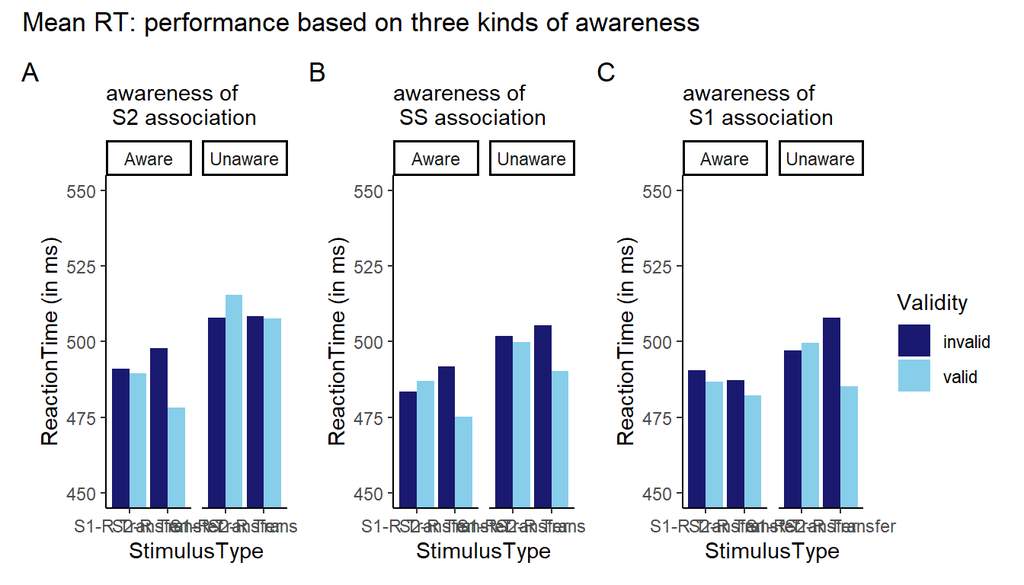

```r
RT3A_2 <- (S2_32 + SS_32 + S1_32)+
  plot_annotation(tag_levels = "A", title = "Mean RT: performance based on three kinds of awareness")+
  plot_layout(guides = "collect")&theme_classic()
RT3A_2
```

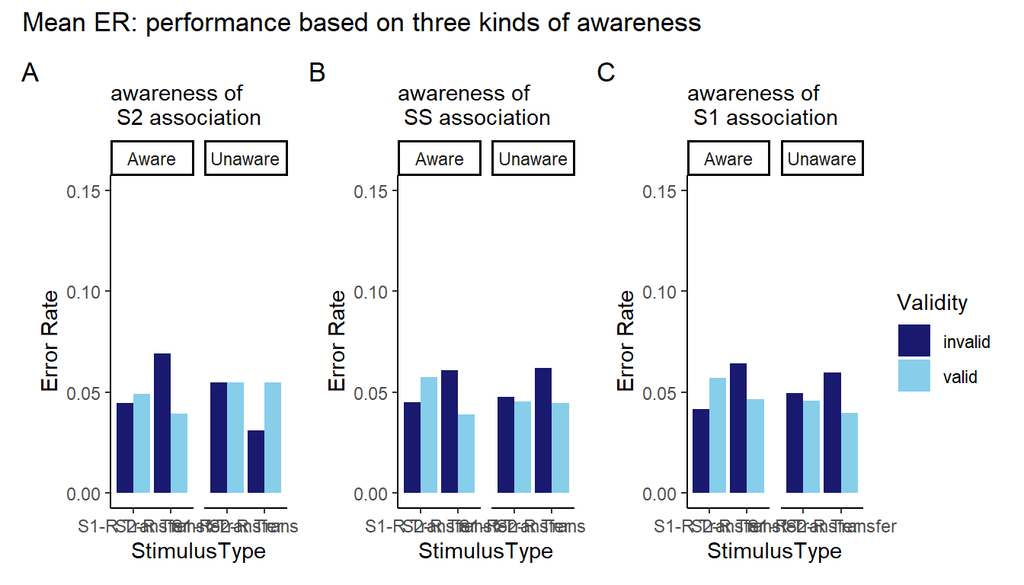

```r
ER3A_2 <- (S2_32_er + SS_32_er + S1_32_er)+
  plot_annotation(tag_levels = "A", title = "Mean ER: performance based on three kinds of awareness")+
  plot_layout(guides = "collect")&theme_classic()
ER3A_2
```

# Exploratory

```r
#creating df with block

Exp1_3.1_block <- Exp1data %>%
  group_by(PROLIFIC_PID,Validity,Condition,BlockNumber) %>%
  filter(Phase == 3.1) %>%
  summarise(ER= mean(ER,na.rm=TRUE),
            RT = mean(RT_io, na.rm = TRUE)) %>%
  rename(StimulusType = Condition)

#participants with NaN

ppNaN <- which(is.nan(Exp1_3.1_block$RT)==TRUE,useNames =TRUE)

ppNaN <- Exp1_3.1_block$PROLIFIC_PID[ppNaN]

#remmoving people who have NaN
Exp1_3.1_block <- Exp1_3.1_block %>%
  filter(!PROLIFIC_PID %in% ppNaN)

##Change to lme4 and use linear mixed effects for ANOVA

## Reaction Time
anova31RT_b <- lmer(data = Exp1_3.1_block, RT~Validity*StimulusType*BlockNumber+ (1|PROLIFIC_PID))
pander(anova(anova31RT_b), style = "rmarkdown", capion = "ANOVA(RT) results including BlockNumber")
```

Type III Analysis of Variance Table with Satterthwaite’s method (continued below)

|  | Sum Sq | Mean Sq | NumDF | DenDF |
| --- | --- | --- | --- | --- |
| **Validity** | 2375 | 2375 | 1 | 774.1 |
| **StimulusType** | 722.1 | 722.1 | 1 | 774.1 |
| **BlockNumber** | 19247 | 19247 | 1 | 774.1 |
| **Validity:StimulusType** | 2993 | 2993 | 1 | 774.1 |
| **Validity:BlockNumber** | 3370 | 3370 | 1 | 774.1 |
| **StimulusType:BlockNumber** | 1645 | 1645 | 1 | 774.1 |
| **Validity:StimulusType:BlockNumber** | 4210 | 4210 | 1 | 774.1 |

|  | F value | Pr(>F) |
| --- | --- | --- |
| **Validity** | 0.8043 | 0.3701 |
| **StimulusType** | 0.2445 | 0.6211 |
| **BlockNumber** | 6.518 | 0.01087 |
| **Validity:StimulusType** | 1.014 | 0.3144 |
| **Validity:BlockNumber** | 1.141 | 0.2857 |
| **StimulusType:BlockNumber** | 0.5572 | 0.4556 |
| **Validity:StimulusType:BlockNumber** | 1.426 | 0.2328 |

```r
mean3_1_b <- summarySEwithin(Exp1_3.1_block, measurevar= "RT", withinvars=c("Validity","StimulusType","BlockNumber"), idvar="PROLIFIC_PID", na.rm=FALSE, conf.interval=.95)

inter3.1b <- ggplot(mean3_1_b, aes(x=StimulusType, y=RT,fill = Validity))+
  geom_bar(stat = "identity",position = position_dodge())+
  geom_errorbar(aes(ymin = RT - ci, ymax = RT + ci),width = .1, size = 1,position = position_dodge(.9))+
  scale_fill_manual(values = c("midnightblue","skyblue"))+
  coord_cartesian(ylim = c(400,550))+
  ylab("ReactionTime (in ms)")+
  xlab("StimulusType")+
  facet_grid(.~BlockNumber)+
  theme(text = element_text(size = 20))


## Error Rate
anova31ER_b <- lmer(data = Exp1_3.1_block, ER~Validity*StimulusType*BlockNumber+ (1|PROLIFIC_PID))

pander(anova(anova31ER_b), style = "rmarkdown", capion = "ANOVA(ER) results including BlockNumber")
```

Type III Analysis of Variance Table with Satterthwaite’s method (continued below)

|  | Sum Sq | Mean Sq | NumDF |
| --- | --- | --- | --- |
| **Validity** | 0.009245 | 0.009245 | 1 |
| **StimulusType** | 0.0008203 | 0.0008203 | 1 |
| **BlockNumber** | 0.01138 | 0.01138 | 1 |
| **Validity:StimulusType** | 0.01373 | 0.01373 | 1 |
| **Validity:BlockNumber** | 0.000195 | 0.000195 | 1 |
| **StimulusType:BlockNumber** | 0.005998 | 0.005998 | 1 |
| **Validity:StimulusType:BlockNumber** | 0.01158 | 0.01158 | 1 |

|  | DenDF | F value | Pr(>F) |
| --- | --- | --- | --- |
| **Validity** | 774.9 | 0.9163 | 0.3387 |
| **StimulusType** | 774.9 | 0.0813 | 0.7756 |
| **BlockNumber** | 775.3 | 1.128 | 0.2885 |
| **Validity:StimulusType** | 774.9 | 1.361 | 0.2438 |
| **Validity:BlockNumber** | 775.3 | 0.01933 | 0.8895 |
| **StimulusType:BlockNumber** | 775.3 | 0.5945 | 0.4409 |
| **Validity:StimulusType:BlockNumber** | 775.3 | 1.148 | 0.2843 |

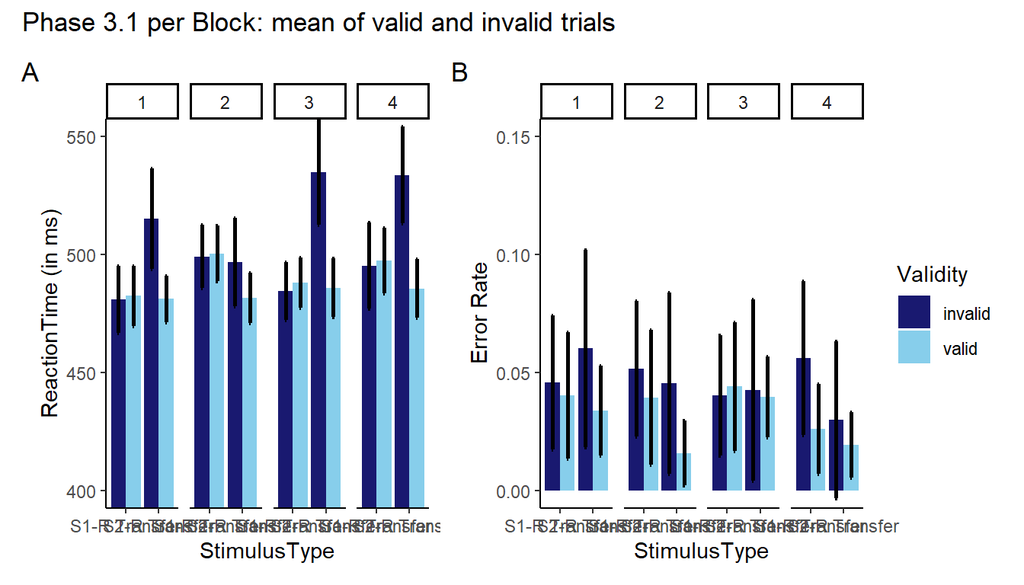

```r
mean3_1_ber <- summarySEwithin(Exp1_3.1_block, measurevar= "ER", withinvars=c("Validity","StimulusType","BlockNumber"), idvar="PROLIFIC_PID", na.rm=FALSE, conf.interval=.95)

inter3.1ber <- ggplot(mean3_1_ber, aes(x=StimulusType, y=ER,fill = Validity))+
  geom_bar(stat = "identity",position = position_dodge())+
  geom_errorbar(aes(ymin = ER - ci, ymax = ER + ci),width = .1, size = 1,position = position_dodge(.9))+
  scale_fill_manual(values = c("midnightblue","skyblue"))+
  coord_cartesian(ylim = c(0,0.15))+
  theme_classic()+
  ylab("Error Rate")+
  xlab("StimulusType")+
  facet_grid(.~BlockNumber)+
  theme(text = element_text(size = 20))


plot3 <- (inter3.1b+inter3.1ber)+
  plot_annotation(tag_levels = "A", title = "Phase 3.1 per Block: mean of valid and invalid trials" )+
  plot_layout(guides = "collect")&theme_classic()
plot3
```

## Block analyses for Phase 3.2

```r
Exp1_3.2_block <- Exp1data %>%
  group_by(PROLIFIC_PID,Validity,Condition,BlockNumber) %>%
  filter(Phase == 3.2) %>%
  summarise(ER= mean(ER,na.rm=TRUE),
            RT = mean(RT_io, na.rm = TRUE)) %>%
  rename(StimulusType = Condition)
mean3_2_b <- summarySEwithin(Exp1_3.2_block, measurevar= "RT", withinvars=c("Validity","StimulusType","BlockNumber"), idvar="PROLIFIC_PID", na.rm=FALSE, conf.interval=.95)
```

```
## Automatically converting the following non-factors to factors: Validity, StimulusType, BlockNumber
```

```r
inter3.2b <- ggplot(mean3_2_b, aes(x=StimulusType, y=RT,fill = Validity))+
  geom_bar(stat = "identity",position = position_dodge())+
  geom_errorbar(aes(ymin = RT - ci, ymax = RT + ci),width = .1, size = 1,position = position_dodge(.9))+
  scale_fill_manual(values = c("midnightblue","skyblue"))+
  coord_cartesian(ylim = c(400,550))+
  ylab("ReactionTime (in ms)")+
  xlab("StimulusType")+
  facet_grid(.~BlockNumber)+
  theme(text = element_text(size = 20))

mean3_2_ber <- summarySEwithin(Exp1_3.2_block, measurevar= "ER", withinvars=c("Validity","StimulusType","BlockNumber"), idvar="PROLIFIC_PID", na.rm=FALSE, conf.interval=.95)
```

```
## Automatically converting the following non-factors to factors: Validity, StimulusType, BlockNumber
```

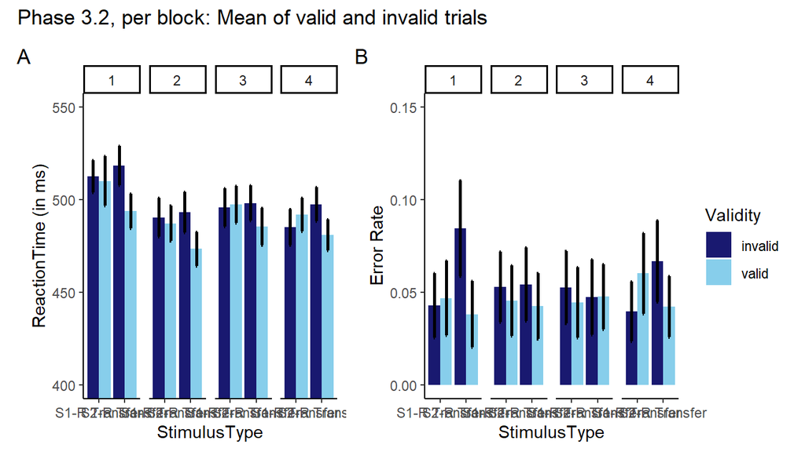

```r
inter3.2ber <- ggplot(mean3_2_ber, aes(x=StimulusType, y=ER,fill = Validity))+
  geom_bar(stat = "identity",position = position_dodge())+
  geom_errorbar(aes(ymin = ER - ci, ymax = ER + ci),width = .1, size = 1,position = position_dodge(.9))+
  scale_fill_manual(values = c("midnightblue","skyblue"))+
  coord_cartesian(ylim = c(0,0.15))+
  ylab("Error Rate")+
  xlab("StimulusType")+
  facet_grid(.~BlockNumber)+
  theme(text = element_text(size = 20))

Plot4 <- (inter3.2b+inter3.2ber)+
  plot_annotation(tag_levels = "A", title = "Phase 3.2, per block: Mean of valid and invalid trials")+
  plot_layout(guides = "collect")&theme_classic()
Plot4
```